# Political_Causal_Language

Calvin Isch

2025-09-11

Ensure package versions match for reproducibility

```r
#renv::init()
#renv::snapshot(prompt = FALSE)

if (!requireNamespace("renv", quietly = TRUE)) install.packages("renv");
renv::restore(prompt = FALSE)
```

Load the data and necessary packages

```r
library(lme4); library(lmerTest); library(ggplot2); library(dplyr); library(tidyr); library(cowplot); library(broom); library(broom.mixed); library(patchwork); library(grid);library(scales); library(lattice); library(DHARMa)
library(irr); library(modelsummary); library(influence.ME); library(coin)
library(sandwich);library(lmtest);library(gt); library(emmeans); library(forcats)
df <- read.csv('political_ratings.csv')

df = df %>% filter(Rating != "") # Remove rows with empty Rating values
# Only removes 25 entries
25 / nrow(df)
```

```
## [1] 0.0001284647
```

```r
# Turn off science notation
options(scipen = 999)
```

# Results section

Descriptives

```r
# Counts and proportions that are apolitical vs political
table(df$Rating)
```

```
##
##      A      P
##  83997 110609
```

```r
prop.table(table(df$Rating))
```

```
##
##        A        P
## 0.431626 0.568374
```

```r
# Counts and proportions of slant
table(df$Slant)
```

```
##
##     1     2     3     4     5     6     7
##     7 12848 27082 67592  2688   391     1
```

```r
prop.table(table(df$Slant))
```

```
##
##              1              2              3              4              5
## 0.000063285989 0.116156913090 0.244844452079 0.611089513512 0.024301819924
##              6              7
## 0.003534974550 0.000009040856
```

```r
# Because so few strong left/right slant combine them to adjacent categories
df$Slant_All <- df$Slant
df <- df %>%
  mutate(Slant = case_when(
    Slant == 1 ~ 2,
    Slant == 7 ~ 6,
    TRUE ~ Slant
  ))

# Proportion of slanted in each category
prop.table(df %>% filter(Rating == "P", Slant != 4) %>% select(Slant) %>% table())
```

```
## Slant
##           2           3           5           6
## 0.298835344 0.629565056 0.062486924 0.009112676
```

```r
# Proportion of slanted left, then right.
0.629 + 0.299
```

```
## [1] 0.928
```

```r
0.062 + 0.009
```

```
## [1] 0.071
```

```r
# Ratio
(df %>% filter(Slant %in% c(1, 2, 3)) %>% nrow()) / (df %>% filter(Slant %in% c(5, 6, 7)) %>% nrow())
```

```
## [1] 12.96656
```

```r
# Recode Decade to account for those with fewer than 10 observations
df <- df %>%
  mutate(Decade = as.character(Decade)) %>%
  mutate(Decade = case_when(
    Decade %in% c("1900", "1910", "1920", "1930", "1940", "2030") ~ "Other",
    TRUE ~ Decade
  ))
table(df$Decade)
```

```
##
##  1950  1960  1970  1980  1990  2000  2010  2020 Other
##    21    76  1063  5271 11906 28896 79702 67657    14
```

```r
# Show proportion political by decade
df %>% group_by(Decade) %>%
  summarize(
    n_total = n(),
    n_P = sum(Rating == "P", na.rm = TRUE),
    prop_P = n_P / n_total
  )
```

```
## # A tibble: 9 × 4
##   Decade n_total   n_P prop_P
##   <chr>    <int> <int>  <dbl>
## 1 1950        21     6  0.286
## 2 1960        76    29  0.382
## 3 1970      1063   493  0.464
## 4 1980      5271  2575  0.489
## 5 1990     11906  5410  0.454
## 6 2000     28896 15469  0.535
## 7 2010     79702 44998  0.565
## 8 2020     67657 41625  0.615
## 9 Other       14     4  0.286
```

```r
# Proportion of political that is slanted by decade
df %>% filter(Rating=="P") %>% group_by(Decade) %>%
  summarize(
    n_total = n(),
    n_S = sum(Slant %in% c(1,2,3,5,6,7), na.rm = TRUE),
    prop_S = n_S / n_total
  )
```

```
## # A tibble: 9 × 4
##   Decade n_total   n_S prop_S
##   <chr>    <int> <int>  <dbl>
## 1 1950         6     0 0
## 2 1960        29     2 0.0690
## 3 1970       493   125 0.254
## 4 1980      2575   520 0.202
## 5 1990      5410  1031 0.191
## 6 2000     15469  4679 0.302
## 7 2010     44998 17090 0.380
## 8 2020     41625 19569 0.470
## 9 Other        4     1 0.25
```

```r
# Proportion balanced or apolitical overall:
((df %>% filter(Rating == "A") %>% nrow()) + (df %>% filter(Slant == "4") %>% nrow())) / nrow(df)
```

```
## [1] 0.7789534
```

Primary Model: (Model F) See other models in SI

```r
df_pol <- df %>%
  mutate(
    Slant_Cat = case_when(
      Rating == "A" ~ "Apolitical",
      Slant == 1 ~ "Strong left",
      Slant == 2 ~ "Left",
      Slant == 3 ~ "Slight left",
      Slant == 4 ~ "Balanced",
      Slant == 5 ~ "Slight right",
      Slant == 6 ~ "Right",
      Slant == 7 ~ "Strong right",
      TRUE ~ as.character(Slant)  # fall-back for any unhandled values
    ))


model_f <- glmer(
  Causal ~ Slant_Cat + (1 | Discipline) + (1 | Decade),
  data = df_pol,
  family = binomial(link = "logit"),
  na.action = na.omit
)
summary(model_f)
```

```
## Generalized linear mixed model fit by maximum likelihood (Laplace
##   Approximation) [glmerMod]
##  Family: binomial  ( logit )
## Formula: Causal ~ Slant_Cat + (1 | Discipline) + (1 | Decade)
##    Data: df_pol
##
##       AIC       BIC    logLik -2*log(L)  df.resid
##  248591.2  248672.6 -124287.6  248575.2    194598
##
## Scaled residuals:
##     Min      1Q  Median      3Q     Max
## -2.0286 -0.9063 -0.4471  0.9309  6.8392
##
## Random effects:
##  Groups     Name        Variance Std.Dev.
##  Decade     (Intercept) 1.712    1.3083
##  Discipline (Intercept) 0.155    0.3937
## Number of obs: 194606, groups:  Decade, 9; Discipline, 8
##
## Fixed effects:
##                       Estimate Std. Error z value             Pr(>|z|)
## (Intercept)           -1.70612    0.15500 -11.007 < 0.0000000000000002 ***
## Slant_CatBalanced     -0.17509    0.01140 -15.354 < 0.0000000000000002 ***
## Slant_CatLeft          0.11573    0.02019   5.732  0.00000000990813139 ***
## Slant_CatRight         0.24738    0.09110   2.715              0.00662 **
## Slant_CatSlight left   0.12136    0.01517   8.001  0.00000000000000124 ***
## Slant_CatSlight right  0.48362    0.04081  11.850 < 0.0000000000000002 ***
## ---
## Signif. codes:  0 '***' 0.001 '**' 0.01 '*' 0.05 '.' 0.1 ' ' 1
##
## Correlation of Fixed Effects:
##             (Intr) Sln_CB Sln_CL Sln_CR Sl_CSl
## Slnt_CtBlnc -0.001
## Slant_CtLft  0.008  0.284
## Slnt_CtRght -0.077  0.036  0.025
## Slnt_CtSlgl -0.004  0.371  0.241  0.026
## Slnt_CtSlgr -0.019  0.122  0.067 -0.004  0.093
```

```r
s      <- summary(model_f)
coefs  <- s$coefficients
ps <- coefs[, "Pr(>|z|)"]
p.adjust(ps[2:6], method = "holm")
```

```
##                                            Slant_CatBalanced
## 0.0000000000000000000000000000000000000000000000000001654817
##                                                Slant_CatLeft
## 0.0000000198162627763268730089265287717253949395512790943030
##                                               Slant_CatRight
## 0.0066176373849880492511443819125815934967249631881713867188
##                                         Slant_CatSlight left
## 0.0000000000000037138746585044069789070948983102897376164285
##                                        Slant_CatSlight right
## 0.0000000000000000000000000000000855955720791241504532806568
```

```r
coefs <- summary(model_f)$coefficients
ci <- confint(model_f, method = "Wald")  # or method = "profile"
odds_ratios <- exp(cbind(coef = fixef(model_f), ci[rownames(ci) %in% names(fixef(model_f)), ]))

round(odds_ratios, 3)
```

```
##                        coef 2.5 % 97.5 %
## (Intercept)           0.182 0.134  0.246
## Slant_CatBalanced     0.839 0.821  0.858
## Slant_CatLeft         1.123 1.079  1.168
## Slant_CatRight        1.281 1.071  1.531
## Slant_CatSlight left  1.129 1.096  1.163
## Slant_CatSlight right 1.622 1.497  1.757
```

Model Comparison of slanted to balanced (OR in abstract)

```r
df_pol <- df_pol %>%
  mutate(Slant_binary = if_else(Slant_All == 4, "Balanced", "Slanted"))


model_b <- glmer(
  Causal ~ Slant_binary + (1 | Discipline) + (1 | Decade),
  data = df_pol %>% filter(Rating == "P"),
  family = binomial(link = "logit"),
  na.action = na.omit
)
summary(model_b)
```

```
## Generalized linear mixed model fit by maximum likelihood (Laplace
##   Approximation) [glmerMod]
##  Family: binomial  ( logit )
## Formula: Causal ~ Slant_binary + (1 | Discipline) + (1 | Decade)
##    Data: df_pol %>% filter(Rating == "P")
##
##       AIC       BIC    logLik -2*log(L)  df.resid
##  144109.3  144147.8  -72050.7  144101.3    110605
##
## Scaled residuals:
##     Min      1Q  Median      3Q     Max
## -1.5520 -0.8910 -0.5965  0.9635  3.6742
##
## Random effects:
##  Groups     Name        Variance Std.Dev.
##  Decade     (Intercept) 0.9277   0.9632
##  Discipline (Intercept) 0.1293   0.3596
## Number of obs: 110609, groups:  Decade, 9; Discipline, 8
##
## Fixed effects:
##                     Estimate Std. Error z value             Pr(>|z|)
## (Intercept)         -1.48125    0.24743  -5.987        0.00000000214 ***
## Slant_binarySlanted  0.32131    0.01318  24.377 < 0.0000000000000002 ***
## ---
## Signif. codes:  0 '***' 0.001 '**' 0.01 '*' 0.05 '.' 0.1 ' ' 1
##
## Correlation of Fixed Effects:
##             (Intr)
## Slnt_bnrySl -0.002
```

```r
coefs <- summary(model_b)$coefficients
ci <- confint(model_b, method = "Wald")  # or method = "profile"
odds_ratios <- exp(cbind(coef = fixef(model_b), ci[rownames(ci) %in% names(fixef(model_b)), ]))

round(odds_ratios, 3)
```

```
##                      coef 2.5 % 97.5 %
## (Intercept)         0.227 0.140  0.369
## Slant_binarySlanted 1.379 1.344  1.415
```

# Plots

Descriptive plot showing political rating and slant over time (2x2)

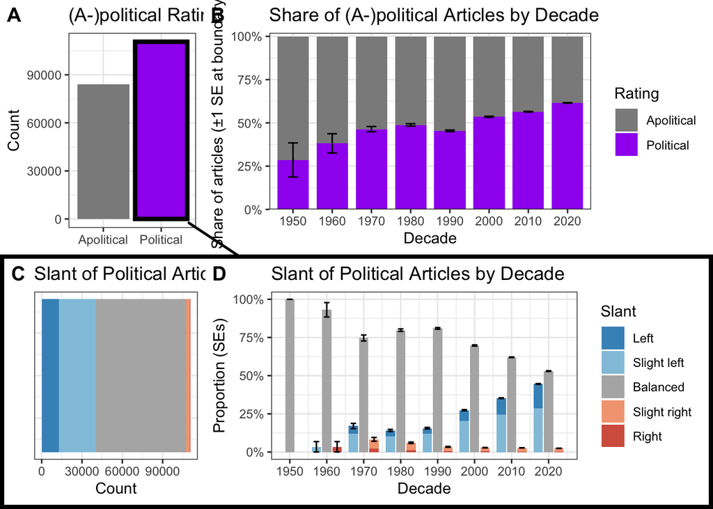

```r
# Make a descriptive 2x2 grid of plots

############# TOP LEFT ########
rating_counts <- df %>%
  count(Rating) %>%
  mutate(Rating = factor(Rating, levels = c("A", "P"))) %>%
  complete(Rating, fill = list(n = 0))

top_left <- ggplot(rating_counts, aes(Rating, n, fill = Rating)) +
  geom_col() +
  scale_fill_manual(values = c("A" = "#8c8c8c", "P" = "purple")) +
  geom_col(
    data   = filter(rating_counts, Rating == "P"),
    aes(Rating, n),
    fill   = NA,
    colour = "black",
    size   = 1.5
  ) +
  scale_x_discrete(labels = c("A" = "Apolitical", "P" = "Political")) +
  labs(title = "(A-)political Ratings", y = "Count", x = NULL) +
  theme_bw() +
  theme(legend.position = "none")
######## TOP RIGHT ########
decade_rate_PA <- df %>%
  filter(Decade != "Other") %>%
  group_by(Decade) %>%
  summarize(
    n_total = n(),
    n_P = sum(Rating == "P", na.rm = TRUE),
    n_A = sum(Rating == "A", na.rm = TRUE),
    .groups = "drop"
  ) %>%
  pivot_longer(c(n_P, n_A), names_to = "Rating", values_to = "n_yes") %>%
  mutate(
    Rating = ifelse(Rating == "n_P", "Political", "Apolitical"),
    prop   = n_yes / n_total,
    se     = sqrt(prop * (1 - prop) / n_total),
    se_lo  = pmax(0, prop - se),
    se_hi  = pmin(1, prop + se)
  )

# Put Political on the bottom, Apolitical on top
decade_rate_PA$Rating <- factor(decade_rate_PA$Rating, levels = c("Apolitical", "Political"))

# Boundary where the stacks meet = height of Political segment
boundary_ci <- decade_rate_PA %>%
  filter(Rating == "Political") %>%
  transmute(
    Decade  = as.factor(Decade),
    meet    = prop,      # boundary height
    meet_lo = se_lo,     # ±1 SE around Political share
    meet_hi = se_hi
  )

top_right <- ggplot(decade_rate_PA,
                    aes(x = as.factor(Decade), y = prop, fill = Rating)) +
  geom_col(width = 0.8) +
  # SE interval at the meeting point with whiskers
  geom_errorbar(
    data = boundary_ci,
    aes(x = Decade, ymin = meet_lo, ymax = meet_hi),
    inherit.aes = FALSE,
    width = 0.25,        # whisker cap width
    linewidth = 0.5
  ) +
  # (optional) center tick at the boundary
  geom_point(
    data = boundary_ci,
    aes(x = Decade, y = meet),
    inherit.aes = FALSE,
    shape = '.', size = 4
  ) +
  scale_y_continuous(labels = percent_format(accuracy = 1),
                     limits = c(0, 1),
                     expand = expansion(mult = c(0, 0.02))) +
  scale_fill_manual(values = c("Apolitical" = "#8c8c8c", "Political" = "purple")) +
  labs(
    x = "Decade",
    y = "Share of articles (±1 SE at boundary)",
    fill = "Rating",
    title = "Share of (A-)political Articles by Decade"
  ) +
  theme_bw()

######### Bottom left ##########
slant_cols  <- c(
  "Strong left"    = "#2166ac",
  "Left"        = "#4393c3",
  "Slight left" = "#92c5de",
  "Balanced"    = "gray70",
  "Slight right"= "#f4a582",
  "Right"       = "#d6604d",
  "Strong right"   = "#b2182b"
)

slant_counts <- df %>%
  filter(Rating == "P") %>%
  count(Slant) %>%
  complete(Slant = 1:7, fill = list(n = 0)) %>%
  arrange(Slant) %>%
  mutate(
    Slant = factor(
      Slant,
      levels = 1:7,
      labels = c(
        "Strong left", "Left", "Slight left",
        "Balanced","Slight right", "Right", "Strong right"
      )
    )
  ) %>% drop_na()

bottom_left <- ggplot(slant_counts, aes(x = 1, y = n, fill = Slant)) +
  geom_col(position = position_stack(reverse = TRUE)) +
  scale_fill_manual(values = slant_cols) +
  coord_flip() +
  labs(
    title = "Slant of Political Articles",
    y     = "Count",
    x     = ""
  ) +
  theme_bw() +
  theme(
    axis.text.y   = element_blank(),
    axis.ticks.y  = element_blank()
  ) +
  theme(legend.position = "none")


####### Bottom right ########
slant_levels <- c("Strong left","Left","Slight left","Balanced",
                  "Slight right","Right","Strong right")

decade_slant_grouped <- df %>%
  filter(Rating == "P", Decade != "Other") %>%
  mutate(
    SlantLabel = case_when(
      Slant == 1 ~ "Strong left",
      Slant == 2 ~ "Left",
      Slant == 3 ~ "Slight left",
      Slant == 4 ~ "Balanced",
      Slant == 5 ~ "Slight right",
      Slant == 6 ~ "Right",
      Slant == 7 ~ "Strong right",
      TRUE ~ NA_character_
    ),
    SideGroup = case_when(
      Slant %in% 1:3 ~ "Left-leaning",
      Slant == 4    ~ "Balanced",
      Slant %in% 5:7 ~ "Right-leaning",
      TRUE ~ NA_character_
    )
  ) %>%
  filter(!is.na(SlantLabel), !is.na(SideGroup)) %>%
  count(Decade, SideGroup, SlantLabel, name = "n") %>%
  group_by(Decade) %>%
  mutate(Proportion = n / sum(n)) %>%   # denom = all Politivsl in that decade
  ungroup() %>%
  mutate(
    DecadeF    = factor(Decade),
    SlantLabel = factor(SlantLabel, levels = slant_levels),
    SideGroup  = factor(SideGroup,  levels = c("Left-leaning","Balanced","Right-leaning"))
  )

# x-offset trick to force stacks within each dodged group
offset_map <- c("Left-leaning" = -0.28, "Balanced" = 0, "Right-leaning" = 0.28)
dec_levels <- levels(decade_slant_grouped$DecadeF)

plot_data <- decade_slant_grouped %>%
  mutate(
    x0   = as.numeric(DecadeF),
    xpos = x0 + unname(offset_map[as.character(SideGroup)])
  )

# --- SEs for each dodged stack (aggregate per SideGroup within decade) ---
stack_summary <- decade_slant_grouped %>%
  group_by(Decade) %>%
  mutate(n_total_decade = sum(n)) %>%
  group_by(Decade, SideGroup, n_total_decade) %>%
  summarise(n_group = sum(n), .groups = "drop") %>%
  mutate(
    Prop = n_group / n_total_decade,
    se   = sqrt(Prop * (1 - Prop) / n_total_decade),
    DecadeF = factor(Decade),
    xpos    = as.numeric(DecadeF) + unname(offset_map[as.character(SideGroup)]),
    p_lo    = pmax(0, Prop - se),
    p_hi    = pmin(1, Prop + se)
  )

bottom_right <- ggplot(plot_data, aes(x = xpos, y = Proportion, fill = SlantLabel)) +
  geom_col(width = 0.25) +  # stacks within each offset (Left/Bal/Right)
  geom_errorbar(
    data = stack_summary,
    aes(x = xpos, ymin = p_lo, ymax = p_hi),
    inherit.aes = FALSE, width = 0.15, linewidth = 0.5, color = "black"
  ) +
  scale_x_continuous(breaks = seq_along(dec_levels), labels = dec_levels) +
  scale_y_continuous(labels = percent_format(accuracy = 1), limits = c(0, 1)) +
  scale_fill_manual(values = slant_cols, breaks = slant_levels) +
  labs(
    x = "Decade",
    y = "Proportion (SEs)",
    fill = "Slant",
    title = "Slant of Political Articles by Decade"
  ) +
  theme_bw() +
  theme(legend.position = "right")

top_row <- plot_grid(top_left,  top_right,  ncol = 2, rel_widths = c(1, 2.5), labels = c('A', 'B'))
bot_row <- plot_grid(bottom_left, bottom_right, ncol = 2, rel_widths = c(1, 2.5), labels = c('C', 'D'))

# Add a thick black border around the entire bottom row
bot_row_bordered <- ggdraw(bot_row) +
  theme(
    plot.background = element_rect(colour = "black", fill = NA, linewidth = 3),
    plot.margin = margin(3, 3, 3, 3)  # optional padding inside the border
  )

# Final figure: top row normal, bottom row with border
final <- plot_grid(top_row, bot_row_bordered, ncol = 1, rel_heights = c(1, 1))

ggdraw(final) +
  draw_grob(segmentsGrob(
    x0 = 0.265, y0 = 0.562, x1 = 0.335, y1 = 0.497,
    gp    = gpar(col = "black", lwd = 2.5),
    arrow = arrow(length = unit(0, "cm"))
  ))
```

```r
ggsave('figures/descriptives_2x2.png', height=6, width=9)
```

Categorical Slant Odds ratios (i.e., main model estimates)

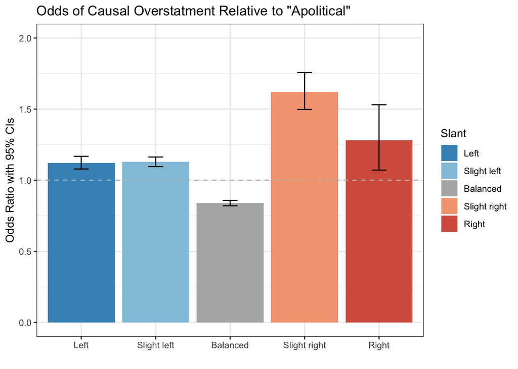

```r
# 1. Extract coefficients and confidence intervals from the model
model_summary <- tidy(model_f, conf.int = TRUE, exponentiate = TRUE)

# 2. Filter for Slant-related terms and clean labels
slant_or <- model_summary %>%
  filter(grepl("Slant", term)) %>%
  select(term, estimate, conf.low, conf.high) %>%
  rename(
    OR = estimate,
    CI_lower = conf.low,
    CI_upper = conf.high
  ) %>%
  mutate(
    err_lower = OR - CI_lower,
    err_upper = CI_upper - OR
  )

slant_or <- slant_or %>%
  mutate(
    Slant = gsub("Slant_Cat", "", term),
    Slant = factor(Slant, levels = c("Strong left","Left","Slight left","Balanced", "Slight right","Right","Strong right"))  # preserve order
  )

# 3. Plot
ggplot(slant_or, aes(x = Slant, y = OR, fill=Slant)) +
  geom_col() +
  geom_errorbar(aes(ymin = CI_lower, ymax = CI_upper), width = 0.2) +
  geom_hline(yintercept = 1, linetype = "dashed", color = "gray") +
  labs(
    title = 'Odds of Causal Overstatment Relative to "Apolitical"',
    y = "Odds Ratio with 95% CIs",
    x = "") +
  scale_fill_manual(values = slant_cols) +
  theme_bw() +
  coord_cartesian(ylim = c(0, 2))
```

```r
ggsave('figures/slant_odds_ratios.png', height=3.5, width=6)
```

# Validation (Methods)

Political relevance and slant validation

```r
df_pv <- read.csv("Political_Validation.csv", fileEncoding = "UTF-8")

cat("N unique scholars:", length(unique(df_pv$Nominator_ID)), "\n")
```

```
## N unique scholars: 42
```

```r
# Groupby scholar and get mean, median, and range of their number of nominations
df_pv %>% group_by(Nominator_ID) %>%
  summarize(
    n = n()
  ) %>%
  summarize(
    mean = mean(n),
    median = median(n),
    min = min(n),
    max = max(n)
  ) %>%
  print()
```

```
## # A tibble: 1 × 4
##    mean median   min   max
##   <dbl>  <dbl> <int> <int>
## 1  6.14      5     1    10
```

```r
print(sort(table(df_pv$Human.Rating), decreasing = TRUE))
```

```
##
##          4 Apolitical          1          2          6          5          3
##         68         47         38         34         24         21         17
##          7
##          9
```

```r
recode_map <- c(
  "Apolitical"   = "Apolitical",
  "Balanced"     = "4",
  "Strong left"  = "1",
  "Left"         = "2",
  "Slightly left"= "3",
  "Slightly right"="5",
  "Right"        = "6",
  "Strong right" = "7"
)

df_pv$Human.Rating <- dplyr::recode(df_pv$Human.Rating, !!!recode_map)

print(paste("Number reviewed by panel:", nrow(df_pv %>%filter(Panel_Reviewed == 1))))
```

```
## [1] "Number reviewed by panel: 38"
```

```r
ct <- table(df_pv$Human.Rating, df_pv$Final.Rating, useNA = "ifany")
ct_m <- addmargins(ct)
rownames(ct_m)[nrow(ct_m)] <- "Total"
colnames(ct_m)[ncol(ct_m)] <- "Total"
cat("\nCrosstab: Human Rating vs Final Rating (with totals)\n")
```

```
##
## Crosstab: Human Rating vs Final Rating (with totals)
```

```r
print(ct_m)
```

```
##
##                1   2   3   4   5   6   7 Apolitical Total
##   1           38   0   0   0   0   0   0          0    38
##   2            1  33   0   0   0   0   0          0    34
##   3            0   0  15   2   0   0   0          0    17
##   4            0   0   0  63   0   0   0          5    68
##   5            0   0   2   0  19   0   0          0    21
##   6            0   3   1   0   0  20   0          0    24
##   7            0   1   0   1   0   0   7          0     9
##   Apolitical   0   0   0  10   0   0   0         37    47
##   Total       39  37  18  76  19  20   7         42   258
```

```r
print(paste("Number requiring updates:", nrow(df_pv %>% filter(Human.Rating != Final.Rating))))
```

```
## [1] "Number requiring updates: 26"
```

```r
print(paste("N Training/Testing:", nrow(df_pv %>% filter(Training == 1)), nrow(df_pv %>% filter(Training == 0))))
```

```
## [1] "N Training/Testing: 129 129"
```

```r
compute_metrics <- function(y_true, y_pred) {
  # Restrict to valid binary labels {0,1}
  ok <- (y_true %in% c(0, 1)) & (y_pred %in% c(0, 1))
  y_true <- y_true[ok]
  y_pred <- y_pred[ok]

  TP <- sum(y_true == 1 & y_pred == 1)
  FP <- sum(y_true == 0 & y_pred == 1)
  FN <- sum(y_true == 1 & y_pred == 0)
  TN <- sum(y_true == 0 & y_pred == 0)
  N  <- TP + FP + FN + TN

  precision <- if ((TP + FP) > 0) TP / (TP + FP) else 0
  recall    <- if ((TP + FN) > 0) TP / (TP + FN) else 0
  f1        <- if ((precision + recall) > 0) 2 * precision * recall / (precision + recall) else 0
  accuracy  <- if (N > 0) (TP + TN) / N else NA_real_

  list(Precision = precision, Recall = recall, F1 = f1, Accuracy = accuracy)
}


# ---------- TRAIN split ----------
df_train <- df_pv %>% filter(Training == 1)

df_train$GPT_Binary <- ifelse(df_train$Rating %in% "Political", 1,
                         ifelse(df_train$Rating %in% "Apolitical", 0, -1))
df_train$Human_Binary <- ifelse(df_train$Final.Rating %in% as.character(1:7), 1,
                           ifelse(df_train$Final.Rating %in% "Apolitical", 0, -1))

cat("\nTRAIN: Crosstab Rating vs Human_Binary (with totals)\n")
```

```
##
## TRAIN: Crosstab Rating vs Human_Binary (with totals)
```

```r
ct_train <- table(df_train$Rating, df_train$Human_Binary, useNA = "ifany")
ct_train_m <- addmargins(ct_train)
rownames(ct_train_m)[nrow(ct_train_m)] <- "Total"
colnames(ct_train_m)[ncol(ct_train_m)] <- "Total"
print(ct_train_m)
```

```
##
##                0   1 Total
##   Apolitical  22   4    26
##   Political    5  98   103
##   Total       27 102   129
```

```r
m <- compute_metrics(df_train$Human_Binary, df_train$GPT_Binary)
cat(sprintf("TRAIN (Political=1): Precision: %.2f, Recall: %.2f, F1 Score: %.2f, Accuracy: %.2f\n",
            m$Precision, m$Recall, m$F1, m$Accuracy))
```

```
## TRAIN (Political=1): Precision: 0.95, Recall: 0.96, F1 Score: 0.96, Accuracy: 0.93
```

```r
# ---------- EVAL split ----------
df_eval <- df_pv %>% filter(Training == 0)

df_eval$GPT_Binary <- ifelse(df_eval$Rating %in% "Political", 1,
                        ifelse(df_eval$Rating %in% "Apolitical", 0, -1))
df_eval$Human_Binary <- ifelse(df_eval$Final.Rating %in% as.character(1:7), 1,
                          ifelse(df_eval$Final.Rating %in% "Apolitical", 0, -1))

cat("\nEVAL: Crosstab Rating vs Human_Binary (with totals)\n")
```

```
##
## EVAL: Crosstab Rating vs Human_Binary (with totals)
```

```r
ct_eval <- table(df_eval$Rating, df_eval$Human_Binary, useNA = "ifany")
ct_eval_m <- addmargins(ct_eval)
rownames(ct_eval_m)[nrow(ct_eval_m)] <- "Total"
colnames(ct_eval_m)[ncol(ct_eval_m)] <- "Total"
print(ct_eval_m)
```

```
##
##                0   1 Total
##   Apolitical   9  12    21
##   Political    6 102   108
##   Total       15 114   129
```

```r
m <- compute_metrics(df_eval$Human_Binary, df_eval$GPT_Binary)
cat(sprintf("EVAL (Political=1): Precision: %.2f, Recall: %.2f, F1 Score: %.2f, Accuracy: %.2f\n",
            m$Precision, m$Recall, m$F1, m$Accuracy))
```

```
## EVAL (Political=1): Precision: 0.94, Recall: 0.89, F1 Score: 0.92, Accuracy: 0.86
```

```r
# ---------- Slant agreement (TRAIN) ----------
df_slant <- df_train %>% filter(Rating == "Political") %>% mutate(
  Slant = ifelse(Slant == "Apolitical", "4", Slant),
  Final.Rating = ifelse(Final.Rating == "Apolitical", "4", Final.Rating)
)

df_slant$Rating <- as.integer(df_slant$Slant)
df_slant$Final.Rating <- as.integer(df_slant$Final.Rating)

cat("\nTRAIN Slant Agreement\n")
```

```
##
## TRAIN Slant Agreement
```

```r
cat("N", nrow(df_slant), "\n")
```

```
## N 103
```

```r
# Quadratic-weighted Cohen's kappa
k_train <- irr::kappa2(data.frame(df_slant$Final.Rating, df_slant$Rating), weight = "squared")
cat(sprintf("Kappa: %.4f\n", k_train$value))
```

```
## Kappa: 0.6605
```

```r
# Spearman correlation
s_train <- suppressWarnings(cor.test(df_slant$Final.Rating, df_slant$Rating, method = "spearman", exact = FALSE))
cat(sprintf("Spearman: rho=%.4f, p=%.3g\n", unname(s_train$estimate), s_train$p.value))
```

```
## Spearman: rho=0.7059, p=8.31e-17
```

```r
# ---------- Slant agreement (EVAL) ----------
df_slant <- df_eval %>% filter(Rating == "Political") %>% mutate(
  Slant = ifelse(Slant == "Apolitical", "4", Slant),
  Final.Rating = ifelse(Final.Rating == "Apolitical", "4", Final.Rating)
)

df_slant$Rating <- as.integer(df_slant$Slant)
df_slant$Final.Rating <- as.integer(df_slant$Final.Rating)

cat("\nEVAL Slant Agreement\n")
```

```
##
## EVAL Slant Agreement
```

```r
cat("N", nrow(df_slant), "\n")
```

```
## N 108
```

```r
k_eval <- irr::kappa2(data.frame(df_slant$Final.Rating, df_slant$Rating), weight = "squared")
cat(sprintf("Kappa: %.4f\n", k_eval$value))
```

```
## Kappa: 0.5886
```

```r
s_eval <- suppressWarnings(cor.test(df_slant$Final.Rating, df_slant$Rating, method = "spearman", exact = FALSE))
cat(sprintf("Spearman: rho=%.4f, p=%.3g\n", unname(s_eval$estimate), s_eval$p.value))
```

```
## Spearman: rho=0.6432, p=6.08e-14
```

Cross Sectional Validation

```r
df_csv <- read.csv('Cross-Sectional-Validation.csv')

coders <- as.data.frame(df_csv[, c("Coder_1","Coder_2","Coder_3")], stringsAsFactors = FALSE)
mat <- t(as.matrix(coders))
irr::kripp.alpha(mat, method = "interval")
```

```
##  Krippendorff's alpha
##
##  Subjects = 200
##    Raters = 3
##     alpha = 0.839
```

```r
m <- compute_metrics(df_csv$Consensus.Binary, df_csv$GPT.Binary)
cat(sprintf("TRAIN (Political=1): Precision: %.2f, Recall: %.2f, F1 Score: %.2f, Accuracy: %.2f\n",
            m$Precision, m$Recall, m$F1, m$Accuracy))
```

```
## TRAIN (Political=1): Precision: 0.83, Recall: 0.91, F1 Score: 0.87, Accuracy: 0.85
```

Causal Validation

```r
df_cv <- read.csv('Causal-Validation.csv')

coders <- as.data.frame(df_cv[, c("Coder_1_binary","Coder_2_binary","Coder_3_binary")], stringsAsFactors = FALSE)
mat <- t(as.matrix(coders))
irr::kripp.alpha(mat, method = "interval")
```

```
##  Krippendorff's alpha
##
##  Subjects = 190
##    Raters = 3
##     alpha = 0.862
```

```r
m <- compute_metrics(df_cv$Final_binary, df_cv$GPT_binary)
cat(sprintf("TRAIN (Political=1): Precision: %.2f, Recall: %.2f, F1 Score: %.2f, Accuracy: %.2f\n",
            m$Precision, m$Recall, m$F1, m$Accuracy))
```

```
## TRAIN (Political=1): Precision: 0.91, Recall: 0.74, F1 Score: 0.81, Accuracy: 0.78
```

```r
# Overall causal percentage
prop.table(table(df$Causal))
```

```
##
##         0         1
## 0.5373421 0.4626579
```

For the methodology (Cross sectional) and causal validations, see the following OSF page for more details: https://osf.io/zpua6/?view_only=e290bc25f1634205b3c9c809fbd4faeb

# Supplemental Materials

Drawing Stratified Random Sample for validation of political slant in cross-sectional articles

```r
# Set seed
set.seed(42)

# Fill NA with "Apolitical"
df <- df %>%
  mutate(Slant = ifelse(is.na(Slant), 7, Slant))  # Treat NA as Apolitical (7)

table(df$Slant)

# Stratified random sample of 40 per category, stratified by Slant (2-6 + Apolitcal)
df_sample <- df %>%
  group_by(Slant) %>%
  slice_sample(n = 20, replace = FALSE) %>%
  ungroup()

# Shuffle and save
df_shuffle <- df_sample[sample(nrow(df_sample)),]

# Get citation information for easy lookup
df_cites <- read.csv("citation.csv")
df_cites$ID <- df_cites$GOID
df_cites <- df_cites %>% select(ID, Title, Date, Authors, Publication.Title)


# Merge
df_shuffle <- df_shuffle %>%
  left_join(df_cites, by = "ID") %>%
  select(ID, Title, Date, Authors, Publication.Title)

write.csv(df_shuffle, 'political_ratings_validation_sample.csv', row.names = FALSE)

# Note: The english version of these articles were not available and were swapped with another randomly selected
# one from their respective slant category:
# 217681138 -> 3108614919
# 2876747201 -> 3143002223
# 2061968330 -> 1443709517
# 205231828 -> 1022612391
# 1928185386 -> 1686086000
```

Checking that sample against manual ratings

```r
df_man_check <- read.csv("Political_Validation_Cross-Sect.csv")

# Fix bad rating
df_man_check <- df_man_check %>% mutate(
  Manual.Rating = recode(Manual.Rating, "Slight Right" = "Slight right"),

) %>% drop_na()

# Make a binary version and also
df_man_check <- df_man_check %>%
  mutate(
    Political_Content = ifelse(Manual.Rating == "Apolitical", 0, 1),
    Manual.Rating = factor(Manual.Rating, levels = c("Left", "Slight left", "Balanced", "Slight right", "Right"))
  )

# Merge with df
df_man_check <- df_man_check %>%
  left_join(df %>% select(ID, Rating, Slant), by = "ID")  %>%
  mutate(Rating = ifelse(Rating == "A", 0, 1))

# Make 2x2 for Political Content vs Rating and calculate Accuracy, Precision, Recall, and F1
tab_polcontent <- table(df_man_check$Political_Content, df_man_check$Rating)
tab_polcontent
```

```
##
##      0  1
##   0 14  7
##   1  6 93
```

```r
# Accuracy, Precision, Recall, and F1 with human as base.
accuracy <- sum(diag(tab_polcontent)) / sum(tab_polcontent)
Precision <- tab_polcontent[2, 2] / sum(tab_polcontent[, 2])
Recall <- tab_polcontent[2, 2] / sum(tab_polcontent[2, ])
F1 <- 2 * (Precision * Recall) / (Precision + Recall)
# Calculate a p-value using a chi-squared test
chisq.test(tab_polcontent)
```

```
##
##  Pearson's Chi-squared test with Yates' continuity correction
##
## data:  tab_polcontent
## X-squared = 41.558, df = 1, p-value = 0.0000000001144
```

```r
# Now limit to political articles by GPT and compare slant with kendal tau
df_man_check <- df_man_check %>% filter(Rating == "1")
tab_slant <- table(df_man_check$Slant, df_man_check$Manual.Rating)
cor.test(df_man_check$Slant, as.numeric(df_man_check$Manual.Rating), method = "kendall")
```

```
##
##  Kendall's rank correlation tau
##
## data:  df_man_check$Slant and as.numeric(df_man_check$Manual.Rating)
## z = 7.6617, p-value = 0.00000000000001834
## alternative hypothesis: true tau is not equal to 0
## sample estimates:
##       tau
## 0.6411058
```

```r
cor.test(df_man_check$Slant, as.numeric(df_man_check$Manual.Rating), method = "spearman")
```

```
##
##  Spearman's rank correlation rho
##
## data:  df_man_check$Slant and as.numeric(df_man_check$Manual.Rating)
## S = 34374, p-value < 0.00000000000000022
## alternative hypothesis: true rho is not equal to 0
## sample estimates:
##       rho
## 0.7435631
```

```r
# Cohen's Kappa
df_man_check$Human <- as.numeric(df_man_check$Manual.Rating)
df_man_check$Human[is.na(df_man_check$Human)] <- 4
kappa2(df_man_check[, c("Slant", "Human")] %>% drop_na(), "squared")
```

```
##  Cohen's Kappa for 2 Raters (Weights: squared)
##
##  Subjects = 100
##    Raters = 2
##     Kappa = 0.551
##
##         z = 7.02
##   p-value = 0.00000000000228
```

# Modeling

Model A

```r
df <- read.csv('political_ratings.csv')

df = df %>%
  filter(Rating != "") %>%
  mutate(Slant_All = Slant,
    Slant = case_when(
      Slant == 1 ~ 2,
      Slant == 7 ~ 6,
      TRUE ~ Slant),
    Decade = as.character(Decade)) %>%
  mutate(Decade = case_when(
    Decade %in% c("1900", "1910", "1920", "1930", "1940", "2030") ~ "Other",
    TRUE ~ Decade
  ))

df_pol <- df %>%
  mutate(Rating = recode(Rating, "A" = "Apolitical", "P" = "Political"),
         Rating = factor(Rating, levels = c("Apolitical", "Political")))
model_a <- glmer(
  Causal ~ Rating + (1 | Discipline) + (1 | Decade),
  data = df_pol,
  family = binomial(link = "logit"),
  na.action = na.omit
)
summary(model_a)
```

```
## Generalized linear mixed model fit by maximum likelihood (Laplace
##   Approximation) [glmerMod]
##  Family: binomial  ( logit )
## Formula: Causal ~ Rating + (1 | Discipline) + (1 | Decade)
##    Data: df_pol
##
##       AIC       BIC    logLik -2*log(L)  df.resid
##  249247.7  249288.4 -124619.8  249239.7    194602
##
## Scaled residuals:
##     Min      1Q  Median      3Q     Max
## -1.5966 -0.9051 -0.4472  0.9912  6.4716
##
## Random effects:
##  Groups     Name        Variance Std.Dev.
##  Decade     (Intercept) 1.7340   1.3168
##  Discipline (Intercept) 0.1471   0.3836
## Number of obs: 194606, groups:  Decade, 9; Discipline, 8
##
## Fixed effects:
##                 Estimate Std. Error z value             Pr(>|z|)
## (Intercept)     -1.71546    0.17444  -9.834 < 0.0000000000000002 ***
## RatingPolitical -0.05342    0.01027  -5.203          0.000000196 ***
## ---
## Signif. codes:  0 '***' 0.001 '**' 0.01 '*' 0.05 '.' 0.1 ' ' 1
##
## Correlation of Fixed Effects:
##             (Intr)
## RatingPltcl -0.002
```

Model B and C

```r
df_pol <- df_pol %>%
  mutate(Slant_binary = if_else(Slant == 4, "Balanced", "Slanted"),
         Slant_abs = abs(Slant - 4))


model_b <- glmer(
  Causal ~ Slant_binary + (1 | Discipline) + (1 | Decade),
  data = df_pol %>% filter(Rating == "Political"),
  family = binomial(link = "logit"),
  na.action = na.omit
)
summary(model_b)
```

```
## Generalized linear mixed model fit by maximum likelihood (Laplace
##   Approximation) [glmerMod]
##  Family: binomial  ( logit )
## Formula: Causal ~ Slant_binary + (1 | Discipline) + (1 | Decade)
##    Data: df_pol %>% filter(Rating == "Political")
##
##       AIC       BIC    logLik -2*log(L)  df.resid
##  144109.3  144147.8  -72050.7  144101.3    110605
##
## Scaled residuals:
##     Min      1Q  Median      3Q     Max
## -1.5520 -0.8910 -0.5965  0.9635  3.6742
##
## Random effects:
##  Groups     Name        Variance Std.Dev.
##  Decade     (Intercept) 0.9277   0.9632
##  Discipline (Intercept) 0.1293   0.3596
## Number of obs: 110609, groups:  Decade, 9; Discipline, 8
##
## Fixed effects:
##                     Estimate Std. Error z value             Pr(>|z|)
## (Intercept)         -1.48125    0.24743  -5.987        0.00000000214 ***
## Slant_binarySlanted  0.32131    0.01318  24.377 < 0.0000000000000002 ***
## ---
## Signif. codes:  0 '***' 0.001 '**' 0.01 '*' 0.05 '.' 0.1 ' ' 1
##
## Correlation of Fixed Effects:
##             (Intr)
## Slnt_bnrySl -0.002
```

```r
model_c <- glmer(
  Causal ~ Slant_abs + (1 | Discipline) + (1 | Decade),
  data = df_pol %>% filter(Rating == "Political"),
  family = binomial(link = "logit"),
  na.action = na.omit
)
summary(model_c)
```

```
## Generalized linear mixed model fit by maximum likelihood (Laplace
##   Approximation) [glmerMod]
##  Family: binomial  ( logit )
## Formula: Causal ~ Slant_abs + (1 | Discipline) + (1 | Decade)
##    Data: df_pol %>% filter(Rating == "Political")
##
##       AIC       BIC    logLik -2*log(L)  df.resid
##  144244.2  144282.7  -72118.1  144236.2    110605
##
## Scaled residuals:
##     Min      1Q  Median      3Q     Max
## -1.6285 -0.8991 -0.5704  0.9802  3.7994
##
## Random effects:
##  Groups     Name        Variance Std.Dev.
##  Decade     (Intercept) 0.9403   0.9697
##  Discipline (Intercept) 0.1278   0.3575
## Number of obs: 110609, groups:  Decade, 9; Discipline, 8
##
## Fixed effects:
##              Estimate Std. Error z value             Pr(>|z|)
## (Intercept) -1.463611   0.323507  -4.524           0.00000606 ***
## Slant_abs    0.196417   0.009162  21.437 < 0.0000000000000002 ***
## ---
## Signif. codes:  0 '***' 0.001 '**' 0.01 '*' 0.05 '.' 0.1 ' ' 1
##
## Correlation of Fixed Effects:
##           (Intr)
## Slant_abs -0.005
```

```r
df_pol <- df_pol %>%
  mutate(Slant_Abs7 = abs(Slant - 4))

model_c_7 <- glmer(
  Causal ~ Slant_Abs7 + (1 | Discipline) + (1 | Decade),
  data = df_pol %>% filter(Rating == "Political"),
  family = binomial(link = "logit"),
  na.action = na.omit
)
summary(model_c_7)
```

```
## Generalized linear mixed model fit by maximum likelihood (Laplace
##   Approximation) [glmerMod]
##  Family: binomial  ( logit )
## Formula: Causal ~ Slant_Abs7 + (1 | Discipline) + (1 | Decade)
##    Data: df_pol %>% filter(Rating == "Political")
##
##       AIC       BIC    logLik -2*log(L)  df.resid
##  144244.2  144282.7  -72118.1  144236.2    110605
##
## Scaled residuals:
##     Min      1Q  Median      3Q     Max
## -1.6285 -0.8991 -0.5704  0.9802  3.7994
##
## Random effects:
##  Groups     Name        Variance Std.Dev.
##  Decade     (Intercept) 0.9403   0.9697
##  Discipline (Intercept) 0.1278   0.3575
## Number of obs: 110609, groups:  Decade, 9; Discipline, 8
##
## Fixed effects:
##              Estimate Std. Error z value             Pr(>|z|)
## (Intercept) -1.463611   0.323507  -4.524           0.00000606 ***
## Slant_Abs7   0.196417   0.009162  21.437 < 0.0000000000000002 ***
## ---
## Signif. codes:  0 '***' 0.001 '**' 0.01 '*' 0.05 '.' 0.1 ' ' 1
##
## Correlation of Fixed Effects:
##            (Intr)
## Slant_Abs7 -0.005
```

Models D & E

```r
df_pol <- df_pol %>%
  mutate(Left_Leaning = if_else(Slant < 4, "Left", "All_Other"),
         Left_Leaning = factor(Left_Leaning, levels = c("All_Other", "Left")))

model_d <- glmer(
  Causal ~ Slant_binary + Left_Leaning + (1 | Discipline) + (1 | Decade),
  data = df_pol %>% filter(Rating == "Political"),
  family = binomial(link = "logit"),
  na.action = na.omit
)
summary(model_d)
```

```
## Generalized linear mixed model fit by maximum likelihood (Laplace
##   Approximation) [glmerMod]
##  Family: binomial  ( logit )
## Formula: Causal ~ Slant_binary + Left_Leaning + (1 | Discipline) + (1 |
##     Decade)
##    Data: df_pol %>% filter(Rating == "Political")
##
##       AIC       BIC    logLik -2*log(L)  df.resid
##  144050.6  144098.7  -72020.3  144040.6    110604
##
## Scaled residuals:
##     Min      1Q  Median      3Q     Max
## -1.7870 -0.8913 -0.5912  0.9618  3.6972
##
## Random effects:
##  Groups     Name        Variance Std.Dev.
##  Decade     (Intercept) 0.9421   0.9706
##  Discipline (Intercept) 0.1265   0.3557
## Number of obs: 110609, groups:  Decade, 9; Discipline, 8
##
## Fixed effects:
##                     Estimate Std. Error z value             Pr(>|z|)
## (Intercept)         -1.48946    0.28799  -5.172  0.00000023171761081 ***
## Slant_binarySlanted  0.60449    0.03848  15.708 < 0.0000000000000002 ***
## Left_LeaningLeft    -0.30726    0.03924  -7.831  0.00000000000000484 ***
## ---
## Signif. codes:  0 '***' 0.001 '**' 0.01 '*' 0.05 '.' 0.1 ' ' 1
##
## Correlation of Fixed Effects:
##             (Intr) Slnt_S
## Slnt_bnrySl  0.010
## Lft_LnngLft -0.011 -0.940
```

```r
model_e <- glmer(
  Causal ~ Slant_abs * Left_Leaning + (1 | Discipline) + (1 | Decade),
  data = df_pol %>% filter(Rating == "Political"),
  family = binomial(link = "logit"),
  na.action = na.omit
)
summary(model_e)
```

```
## Generalized linear mixed model fit by maximum likelihood (Laplace
##   Approximation) [glmerMod]
##  Family: binomial  ( logit )
## Formula: Causal ~ Slant_abs * Left_Leaning + (1 | Discipline) + (1 | Decade)
##    Data: df_pol %>% filter(Rating == "Political")
##
##       AIC       BIC    logLik -2*log(L)  df.resid
##  144092.3  144150.0  -72040.2  144080.3    110603
##
## Scaled residuals:
##     Min      1Q  Median      3Q     Max
## -2.1197 -0.8922 -0.5918  0.9607  3.7373
##
## Random effects:
##  Groups     Name        Variance Std.Dev.
##  Decade     (Intercept) 0.9544   0.9769
##  Discipline (Intercept) 0.1268   0.3560
## Number of obs: 110609, groups:  Decade, 9; Discipline, 8
##
## Fixed effects:
##                            Estimate Std. Error z value             Pr(>|z|)
## (Intercept)                -1.49255    0.25750  -5.796        0.00000000678 ***
## Slant_abs                   0.47095    0.03289  14.319 < 0.0000000000000002 ***
## Left_LeaningLeft            0.30100    0.03189   9.439 < 0.0000000000000002 ***
## Slant_abs:Left_LeaningLeft -0.47630    0.03943 -12.080 < 0.0000000000000002 ***
## ---
## Signif. codes:  0 '***' 0.001 '**' 0.01 '*' 0.05 '.' 0.1 ' ' 1
##
## Correlation of Fixed Effects:
##             (Intr) Slnt_b Lft_LL
## Slant_abs   -0.006
## Lft_LnngLft -0.003  0.041
## Slnt_b:L_LL  0.005 -0.830 -0.539
```

```r
model_e_7 <- glmer(
  Causal ~ Slant_Abs7 * Left_Leaning + (1 | Discipline) + (1 | Decade),
  data = df_pol %>% filter(Rating == "Political"),
  family = binomial(link = "logit"),
  na.action = na.omit
)
summary(model_e_7)
```

```
## Generalized linear mixed model fit by maximum likelihood (Laplace
##   Approximation) [glmerMod]
##  Family: binomial  ( logit )
## Formula: Causal ~ Slant_Abs7 * Left_Leaning + (1 | Discipline) + (1 |
##     Decade)
##    Data: df_pol %>% filter(Rating == "Political")
##
##       AIC       BIC    logLik -2*log(L)  df.resid
##  144092.3  144150.0  -72040.2  144080.3    110603
##
## Scaled residuals:
##     Min      1Q  Median      3Q     Max
## -2.1197 -0.8922 -0.5918  0.9607  3.7373
##
## Random effects:
##  Groups     Name        Variance Std.Dev.
##  Decade     (Intercept) 0.9544   0.9769
##  Discipline (Intercept) 0.1268   0.3560
## Number of obs: 110609, groups:  Decade, 9; Discipline, 8
##
## Fixed effects:
##                             Estimate Std. Error z value             Pr(>|z|)
## (Intercept)                 -1.49255    0.25750  -5.796        0.00000000678
## Slant_Abs7                   0.47095    0.03289  14.319 < 0.0000000000000002
## Left_LeaningLeft             0.30100    0.03189   9.439 < 0.0000000000000002
## Slant_Abs7:Left_LeaningLeft -0.47630    0.03943 -12.080 < 0.0000000000000002
##
## (Intercept)                 ***
## Slant_Abs7                  ***
## Left_LeaningLeft            ***
## Slant_Abs7:Left_LeaningLeft ***
## ---
## Signif. codes:  0 '***' 0.001 '**' 0.01 '*' 0.05 '.' 0.1 ' ' 1
##
## Correlation of Fixed Effects:
##             (Intr) Sln_A7 Lft_LL
## Slant_Abs7  -0.006
## Lft_LnngLft -0.003  0.041
## Sln_A7:L_LL  0.005 -0.830 -0.539
```

Model F

```r
df_pol <- df %>%
  mutate(
    Slant_Cat = case_when(
      Rating == "A" ~ "Apolitical",
      Slant == 1 ~ "Strong left",
      Slant == 2 ~ "Left",
      Slant == 3 ~ "Slight left",
      Slant == 4 ~ "Balanced",
      Slant == 5 ~ "Slight right",
      Slant == 6 ~ "Right",
      Slant == 7 ~ "Strong right",
      TRUE ~ as.character(Slant)  # fall-back for any unhandled values
    ))


model_f <- glmer(
  Causal ~ Slant_Cat + (1 | Discipline) + (1 | Decade),
  data = df_pol,
  family = binomial(link = "logit"),
  na.action = na.omit
)
summary(model_f)
```

```
## Generalized linear mixed model fit by maximum likelihood (Laplace
##   Approximation) [glmerMod]
##  Family: binomial  ( logit )
## Formula: Causal ~ Slant_Cat + (1 | Discipline) + (1 | Decade)
##    Data: df_pol
##
##       AIC       BIC    logLik -2*log(L)  df.resid
##  248591.2  248672.6 -124287.6  248575.2    194598
##
## Scaled residuals:
##     Min      1Q  Median      3Q     Max
## -2.0286 -0.9063 -0.4471  0.9309  6.8392
##
## Random effects:
##  Groups     Name        Variance Std.Dev.
##  Decade     (Intercept) 1.712    1.3083
##  Discipline (Intercept) 0.155    0.3937
## Number of obs: 194606, groups:  Decade, 9; Discipline, 8
##
## Fixed effects:
##                       Estimate Std. Error z value             Pr(>|z|)
## (Intercept)           -1.70612    0.15500 -11.007 < 0.0000000000000002 ***
## Slant_CatBalanced     -0.17509    0.01140 -15.354 < 0.0000000000000002 ***
## Slant_CatLeft          0.11573    0.02019   5.732  0.00000000990813139 ***
## Slant_CatRight         0.24738    0.09110   2.715              0.00662 **
## Slant_CatSlight left   0.12136    0.01517   8.001  0.00000000000000124 ***
## Slant_CatSlight right  0.48362    0.04081  11.850 < 0.0000000000000002 ***
## ---
## Signif. codes:  0 '***' 0.001 '**' 0.01 '*' 0.05 '.' 0.1 ' ' 1
##
## Correlation of Fixed Effects:
##             (Intr) Sln_CB Sln_CL Sln_CR Sl_CSl
## Slnt_CtBlnc -0.001
## Slant_CtLft  0.008  0.284
## Slnt_CtRght -0.077  0.036  0.025
## Slnt_CtSlgl -0.004  0.371  0.241  0.026
## Slnt_CtSlgr -0.019  0.122  0.067 -0.004  0.093
```

```r
s      <- summary(model_f)
coefs  <- s$coefficients
ps <- coefs[, "Pr(>|z|)"]
p.adjust(ps[2:6], method = "holm")
```

```
##                                            Slant_CatBalanced
## 0.0000000000000000000000000000000000000000000000000001654817
##                                                Slant_CatLeft
## 0.0000000198162627763268730089265287717253949395512790943030
##                                               Slant_CatRight
## 0.0066176373849880492511443819125815934967249631881713867188
##                                         Slant_CatSlight left
## 0.0000000000000037138746585044069789070948983102897376164285
##                                        Slant_CatSlight right
## 0.0000000000000000000000000000000855955720791241504532806568
```

```r
coefs <- summary(model_f)$coefficients
ci <- confint(model_f, method = "Wald")  # or method = "profile"
odds_ratios <- exp(cbind(coef = fixef(model_f), ci[rownames(ci) %in% names(fixef(model_f)), ]))

round(odds_ratios, 3)
```

```
##                        coef 2.5 % 97.5 %
## (Intercept)           0.182 0.134  0.246
## Slant_CatBalanced     0.839 0.821  0.858
## Slant_CatLeft         1.123 1.079  1.168
## Slant_CatRight        1.281 1.071  1.531
## Slant_CatSlight left  1.129 1.096  1.163
## Slant_CatSlight right 1.622 1.497  1.757
```

All models in nice table

```r
modelsummary(
  list(
    "Apolitical vs Political" = model_a,
    "Slanted vs Balanced" = model_b,
    "Slant Abs Distance" = model_c,
    "Slanted x Left Lean" = model_d,
    "Slant Abs x Left Lean" = model_e,
    "Non-linear Slant" = model_f
  ),
  stars = TRUE,
  estimate = "{estimate} ({std.error})",
  statistic = NULL,
  confint = FALSE,
  gof_omit = "IC|Log|Adj",  # omit less-relevant goodness-of-fit stats
  title = "Comparison of Logistic Models Predicting Causal Language"
)
```

|  | Apolitical vs Political | Slanted vs Balanced | Slant Abs Distance | Slanted x Left Lean | Slant Abs x Left Lean | Non-linear Slant |
| --- | --- | --- | --- | --- | --- | --- |
| (Intercept) | -1.715 (0.174) | -1.481 (0.247) | -1.464 (0.324) | -1.489 (0.288) | -1.493 (0.257) | -1.706 (0.155) |
| RatingPolitical | -0.053 (0.010) |  |  |  |  |  |
| Slant_binarySlanted |  | 0.321 (0.013) |  | 0.604 (0.038) |  |  |
| Slant_abs |  |  | 0.196 (0.009) |  | 0.471 (0.033) |  |
| Left_LeaningLeft |  |  |  | -0.307 (0.039) | 0.301 (0.032) |  |
| Slant_abs × Left_LeaningLeft |  |  |  |  | -0.476 (0.039) |  |
| Slant_CatBalanced |  |  |  |  |  | -0.175 (0.011) |
| Slant_CatLeft |  |  |  |  |  | 0.116 (0.020) |
| Slant_CatRight |  |  |  |  |  | 0.247 (0.091) |
| Slant_CatSlight left |  |  |  |  |  | 0.121 (0.015) |
| Slant_CatSlight right |  |  |  |  |  | 0.484 (0.041) |
| SD (Intercept Decade) | 1.317 | 0.963 | 0.970 | 0.971 | 0.977 | 1.308 |
| SD (Intercept Discipline) | 0.384 | 0.360 | 0.357 | 0.356 | 0.356 | 0.394 |
| Num.Obs. | 194606 | 110609 | 110609 | 110609 | 110609 | 194606 |
| R2 Marg. | 0.000 | 0.006 | 0.004 | 0.006 | 0.006 | 0.003 |
| R2 Cond. | 0.364 | 0.247 | 0.248 | 0.250 | 0.252 | 0.364 |
| RMSE | 0.47 | 0.48 | 0.48 | 0.48 | 0.48 | 0.47 |

+ p < 0.1, * p < 0.05, ** p < 0.01, *** p < 0.001

```r
models <- list(
  "Apolitical vs Political" = model_a,
  "Slanted vs Balanced"     = model_b,
  "Slant Abs Distance"      = model_c,
  "Slanted x Left Lean"     = model_d,
  "Slant Abs x Left Lean"   = model_e,
  "Non-linear Slant"        = model_f
)

dir.create("figures", showWarnings = FALSE)

modelsummary(
  models,
  exponentiate = TRUE,
  estimate     = "{estimate}",
  statistic    = "[{conf.low}, {conf.high}]",
  tidy_args    = list(conf.int = TRUE, conf.level = 0.95),
  gof_omit     = ".*",
  title        = "Odds Ratios with 95% Wald CIs",
  output       = "figures/model_summary.html"   # writes file directly
)


ggsave('figures/model_summary.png', height=8, width=8)
```

# Residual Analysis

```r
# Not singular
isSingular(model_f)
```

```
## [1] FALSE
```

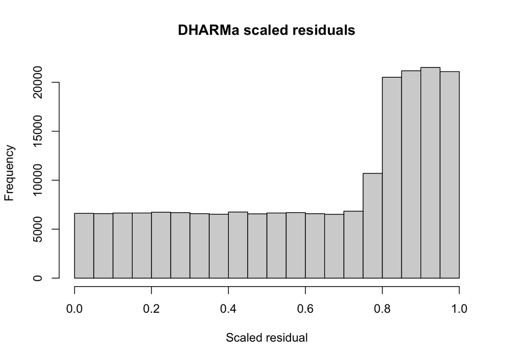

```r
# Normality of residuals histogram


## Simulate residuals that respect the binomial GLMM structure
sim <- simulateResiduals(fittedModel = model_f, n = 1000)  # increase n if you like
hist(sim$scaledResiduals, breaks = 30,
     main = "DHARMa scaled residuals",
     xlab = "Scaled residual")
```

```r
testUniformity(sim)   # Highly significant deviation from uniformity - addressed with random slopes
```

```
## DHARMa:testOutliers with type = binomial may have inflated Type I error rates for integer-valued distributions. To get a more exact result, it is recommended to re-run testOutliers with type = 'bootstrap'. See ?testOutliers for details
```

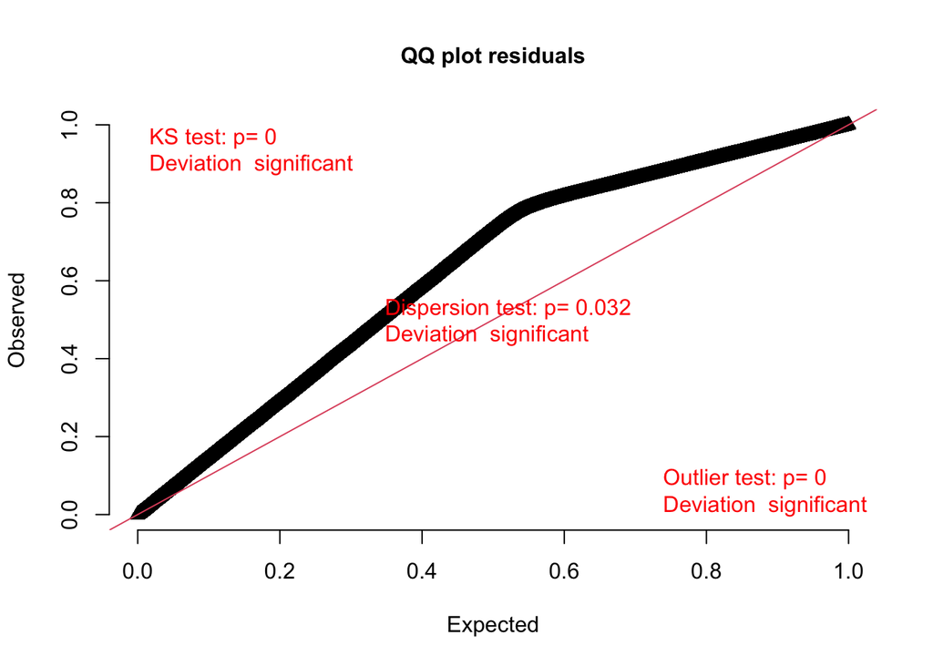

```
##
##  Asymptotic one-sample Kolmogorov-Smirnov test
##
## data:  simulationOutput$scaledResiduals
## D = 0.24216, p-value < 0.00000000000000022
## alternative hypothesis: two-sided
```

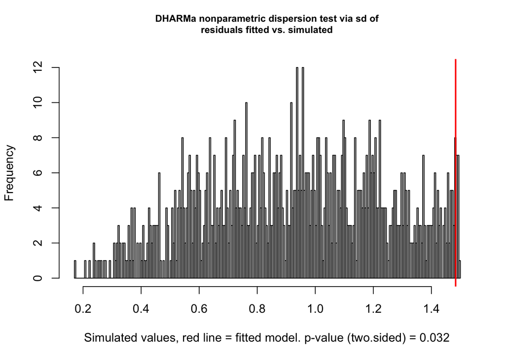

```
##
##  DHARMa nonparametric dispersion test via sd of residuals fitted vs.
##  simulated
##
## data:  simulationOutput
## dispersion = 1.5878, p-value = 0.032
## alternative hypothesis: two.sided
```

```r
testDispersion(sim)
```

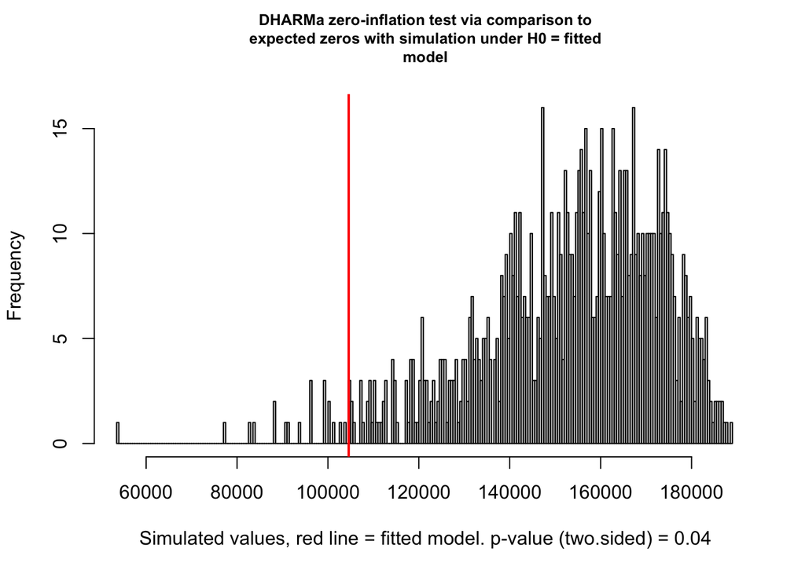

```
##
##  DHARMa zero-inflation test via comparison to expected zeros with
##  simulation under H0 = fitted model
##
## data:  simulationOutput
## ratioObsSim = 0.68183, p-value = 0.04
## alternative hypothesis: two.sided
```

```r
testZeroInflation(sim)
```

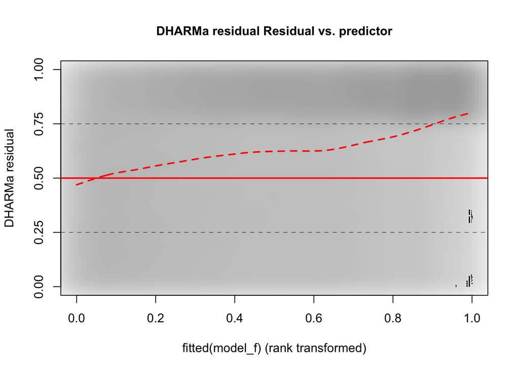

```r
plotResiduals(sim, fitted(model_f))
```

```r
# Significant outliers
testOutliers(sim)
```

```
## DHARMa:testOutliers with type = binomial may have inflated Type I error rates for integer-valued distributions. To get a more exact result, it is recommended to re-run testOutliers with type = 'bootstrap'. See ?testOutliers for details
```

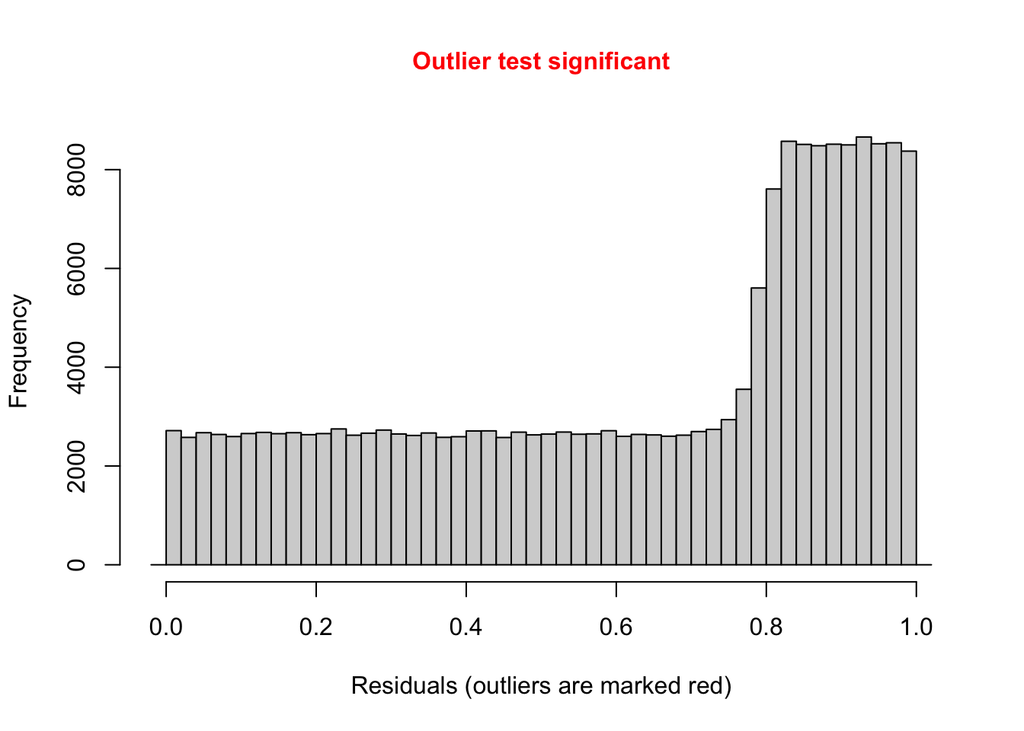

```
##
##  DHARMa outlier test based on exact binomial test with approximate
##  expectations
##
## data:  sim
## outliers at both margin(s) = 541, observations = 194606, p-value =
## 0.0000000000002877
## alternative hypothesis: true probability of success is not equal to 0.001998002
## 95 percent confidence interval:
##  0.002550911 0.003024045
## sample estimates:
## frequency of outliers (expected: 0.001998001998002 )
##                                          0.002779976
```

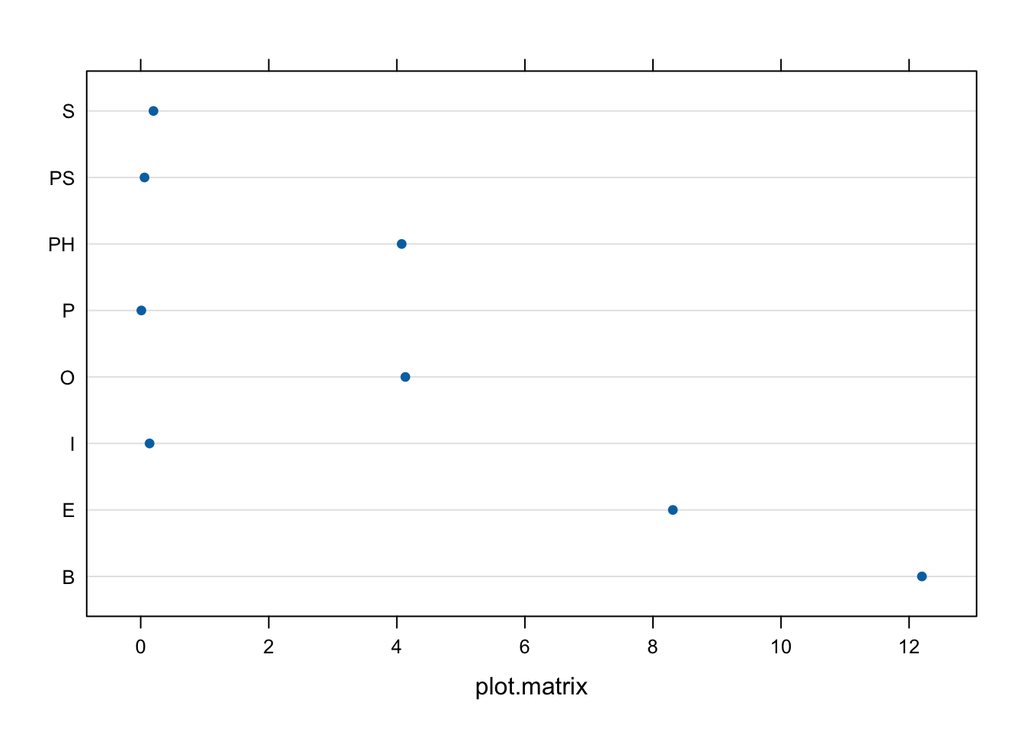

```r
infl <- influence(model_f, group = "Discipline")
plot(infl, which = "cook")
```

```r
cd <- cooks.distance(infl)
cd
```

```
##           [,1]
## B  12.20053178
## E   8.31091719
## I   0.13892289
## O   4.13328556
## P   0.01024145
## PH  4.07581793
## PS  0.05974115
## S   0.19961696
```

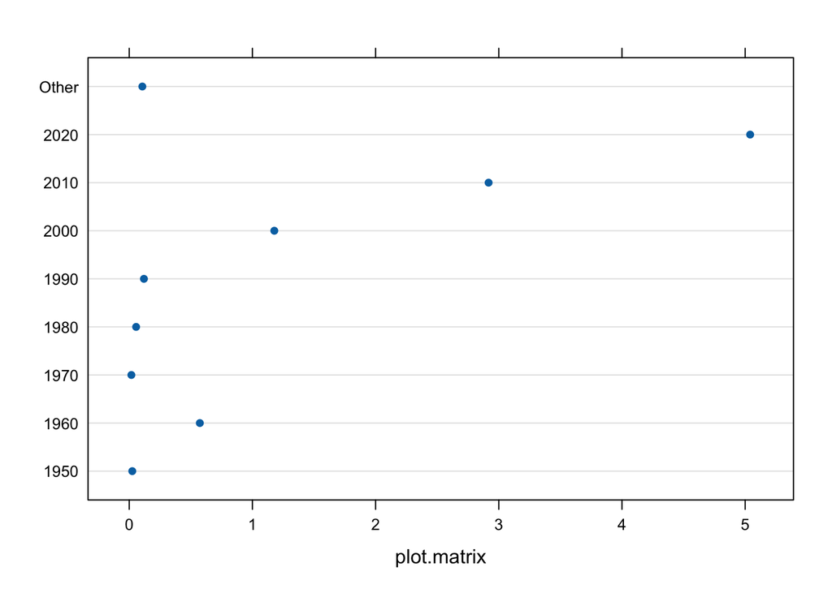

```r
infl_dec  <- influence(model_f, group = "Decade")
plot(infl_dec, which = "cook")
```

```r
cd <- cooks.distance(infl_dec)
cd
```

```
##             [,1]
## 1950  0.02497965
## 1960  0.57341212
## 1970  0.01765853
## 1980  0.05615339
## 1990  0.11952787
## 2000  1.17793746
## 2010  2.91740006
## 2020  5.04066015
## Other 0.10663048
```

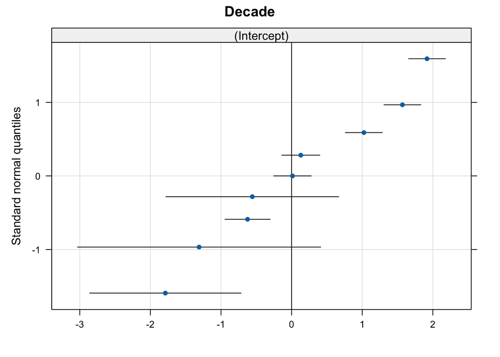

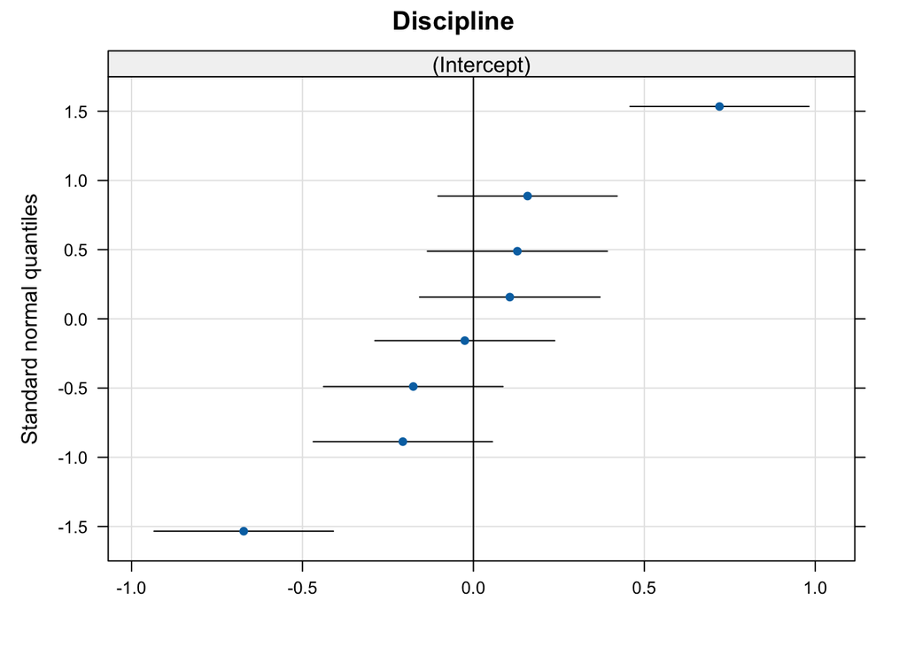

```r
# Random effects centered at 0
re <- ranef(model_f, condVar = TRUE)
lattice::qqmath(re)  # QQ plots by group
```

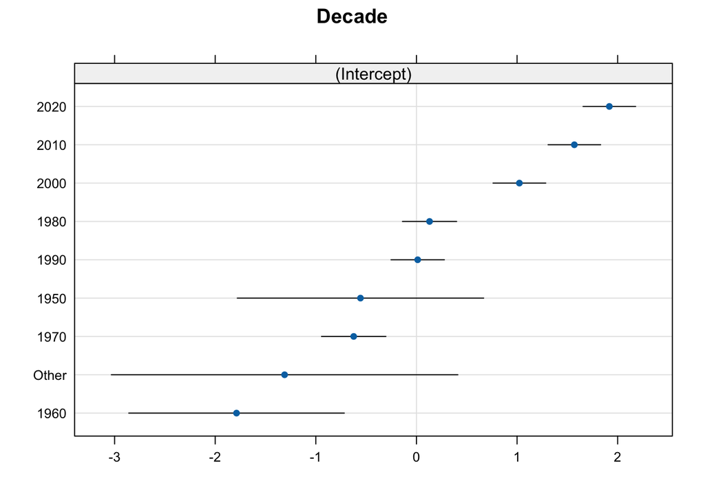

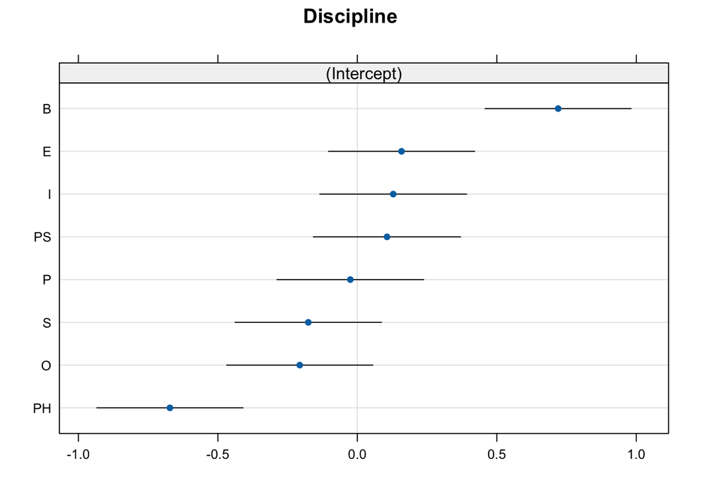

```r
lattice::dotplot(re)
```

# Robustness checks

First attempt alternative MLM specifications (This takes quite some time and just confirms that alternative approaches are necessary)

```r
# Random slopes:
model_f_slopes <- glmer(
  Causal ~ Slant_Cat + (1 + Slant_Cat | Discipline) + (1 | Decade),
  data = df_pol,
  family = binomial(link = "logit"),
  na.action = na.omit
)

# Adding slopes for discipline produces singular fit
summary(model_f_slopes)
isSingular(model_f_slopes)

model_f_slopes <- glmer(
  Causal ~ Slant_Cat + (1 | Discipline) + (1 + Slant_Cat | Decade),
  data = df_pol,
  family = binomial(link = "logit"),
  na.action = na.omit
)
# Same for Decade
summary(model_f_slopes)
isSingular(model_f_slopes)


# Try simplifying the structure
df_pol <- df_pol %>%
  mutate(slant_quad = case_when(
    Slant_Cat == "Apolitical" ~ "Apolitical",
    Slant_Cat == "Balanced"   ~ "Balanced",
    Slant_Cat == "Slight left" ~ "Left-slant",
    Slant_Cat == "Left" ~ "Left-slant",
    TRUE                      ~ "Right-slant"
  ))
# Make "Balanced" the reference
df_pol$slant_quad <- factor(df_pol$slant_quad, levels = c("Balanced", "Apolitical", "Left-slant",'Right-slant'))

model_f_slopes <- glmer(
  Causal ~ slant_quad + (1 + slant_quad | Discipline) + (1 | Decade),
  data = df_pol,
  family = binomial(link = "logit"),
  na.action = na.omit
)

isSingular(model_f_slopes)

summary(model_f_slopes)

## Simulate residuals that respect the binomial GLMM structure
sim <- simulateResiduals(fittedModel = model_f_slopes, n = 1000)
hist(sim$scaledResiduals, breaks = 30,
     main = "DHARMa scaled residuals",
     xlab = "Scaled residual")

testUniformity(sim)
testDispersion(sim)
testZeroInflation(sim)
plotResiduals(sim, fitted(model_f))
testOutliers(sim)
# all of the residual issues remain



infl <- influence(model_f, group = "Discipline")
plot(infl, which = "cook")
cd <- cooks.distance(infl)
cd

# OLRE attempt
df_pol$obs <- seq_len(nrow(df_pol))
m_olre <- glmer(Causal ~ slant_quad + (1 | Discipline) + (1 | Decade) + (1 | obs),
                data=df_pol, family=binomial,
                control=glmerControl(optimizer="bobyqa", optCtrl=list(maxfun=2e5)))

m_cloglog <- update(m_olre, family = binomial(link = "cloglog"))
m_probit  <- update(m_olre, family = binomial(link = "probit"))


# Further coarsening
model_f_slopes <- glmer(
  Causal ~ slant_tri + (1 + slant_tri | Discipline) + (1 | Decade),
  data = df_pol,
  family = binomial(link = "logit"),
  na.action = na.omit
)
df_pol <- df_pol %>%
  mutate(slant_tri = case_when(
    Slant_Cat == "Apolitical" ~ "Apolitical",
    Slant_Cat == "Balanced"   ~ "Balanced",
    TRUE                      ~ "Slanted"
  ))
# Make "Balanced" the reference
df_pol$slant_tri <- factor(df_pol$slant_tri, levels = c("Balanced", "Apolitical", "Slanted"))

sim <- simulateResiduals(fittedModel = model_f_slopes, n = 1000)
hist(sim$scaledResiduals, breaks = 30,
     main = "DHARMa scaled residuals",
     xlab = "Scaled residual")

testUniformity(sim)
testDispersion(sim)
testZeroInflation(sim)
plotResiduals(sim, fitted(model_f))
testOutliers(sim)
```

Nonparametric approaches

```r
ps <- c()
# Apolitical vs Political
df2 <- df_pol %>%
  mutate(Slanted = ifelse(Slant_Cat %in% c("Slight left","Left","Strong Left",
                                           "Slight right","Right","Strong Right", "Balanced"), 1L,0L),
         Decade = ifelse(Decade %in% c("1950","1960","1970","1980"), "Other", Decade))
df2$stratum <- interaction(df2$Discipline, df2$Decade, drop = TRUE)

tab <- xtabs(~ Slanted + Causal + stratum, data = df2)
tab_d <- array(as.numeric(tab), dim = dim(tab), dimnames = dimnames(tab))
cmh <- mantelhaen.test(tab_d, correct = TRUE)
cmh
```

```
##
##  Mantel-Haenszel chi-squared test with continuity correction
##
## data:  tab_d
## Mantel-Haenszel X-squared = 19.139, df = 1, p-value = 0.00001215
## alternative hypothesis: true common odds ratio is not equal to 1
## 95 percent confidence interval:
##  0.9366372 0.9753524
## sample estimates:
## common odds ratio
##         0.9557988
```

```r
ps <- c(ps, cmh$p.value)

# Apolitical vs Balanced
df2 <- df_pol %>%
  mutate(Slanted = ifelse(Slant_Cat %in% c("Balanced"), 1L,
                          ifelse(Slant_Cat == "Apolitical", 0L, NA_integer_)),
         Decade = ifelse(Decade %in% c("1950","1960","1970","1980"), "Other", Decade)) %>%
  filter(!is.na(Slanted))
df2$stratum <- interaction(df2$Discipline, df2$Decade, drop = TRUE)
tab <- xtabs(~ Slanted + Causal + stratum, data = df2)
tab_d <- array(as.numeric(tab), dim = dim(tab), dimnames = dimnames(tab))
cmh <- mantelhaen.test(tab_d, correct = TRUE)  # or exact=TRUE if you prefer
cmh
```

```
##
##  Mantel-Haenszel chi-squared test with continuity correction
##
## data:  tab_d
## Mantel-Haenszel X-squared = 204.45, df = 1, p-value <
## 0.00000000000000022
## alternative hypothesis: true common odds ratio is not equal to 1
## 95 percent confidence interval:
##  0.8280653 0.8667142
## sample estimates:
## common odds ratio
##         0.8471694
```

```r
ps <- c(ps, cmh$p.value)

# Slanted vs Apolitical
df2 <- df_pol %>%
  mutate(Slanted = ifelse(Slant_Cat %in% c("Slight left","Left","Strong Left",
                                           "Slight right","Right","Strong Right"), 1L,
                          ifelse(Slant_Cat == "Apolitical", 0L, NA_integer_)),
         Decade = ifelse(Decade %in% c("1950","1960","1970","1980"), "Other", Decade)) %>%
  filter(!is.na(Slanted))
df2$stratum <- interaction(df2$Discipline, df2$Decade, drop = TRUE)
tab <- xtabs(~ Slanted + Causal + stratum, data = df2)
tab_d <- array(as.numeric(tab), dim = dim(tab), dimnames = dimnames(tab))
cmh <- mantelhaen.test(tab_d, correct = TRUE)  # or exact=TRUE if you prefer
cmh
```

```
##
##  Mantel-Haenszel chi-squared test with continuity correction
##
## data:  tab_d
## Mantel-Haenszel X-squared = 194.54, df = 1, p-value <
## 0.00000000000000022
## alternative hypothesis: true common odds ratio is not equal to 1
## 95 percent confidence interval:
##  1.176619 1.241386
## sample estimates:
## common odds ratio
##          1.208569
```

```r
ps <- c(ps, cmh$p.value)

# Slanted vs Balanced
df2 <- df_pol %>%
  mutate(Slanted = ifelse(Slant_Cat %in% c("Slight left","Left","Strong Left",
                                           "Slight right","Right","Strong Right"), 1L,
                          ifelse(Slant_Cat == "Balanced", 0L, NA_integer_)),
         Decade = ifelse(Decade %in% c("1950","1960","1970","1980"), "Other", Decade)) %>%
  filter(!is.na(Slanted))
df2$stratum <- interaction(df2$Discipline, df2$Decade, drop = TRUE)
tab <- xtabs(~ Slanted + Causal + stratum, data = df2)
tab_d <- array(as.numeric(tab), dim = dim(tab), dimnames = dimnames(tab))
cmh <- mantelhaen.test(tab_d, correct = TRUE)  # or exact=TRUE if you prefer
cmh
```

```
##
##  Mantel-Haenszel chi-squared test with continuity correction
##
## data:  tab_d
## Mantel-Haenszel X-squared = 611.51, df = 1, p-value <
## 0.00000000000000022
## alternative hypothesis: true common odds ratio is not equal to 1
## 95 percent confidence interval:
##  1.350658 1.422600
## sample estimates:
## common odds ratio
##          1.386162
```

```r
ps <- c(ps, cmh$p.value)

# Left slanted vs Balanced
df2 <- df_pol %>%
  mutate(Slanted = ifelse(Slant_Cat %in% c("Slight left","Left","Strong Left"), 1L,
                          ifelse(Slant_Cat == "Balanced", 0L, NA_integer_)),
         Decade = ifelse(Decade %in% c("1950","1960","1970","1980"), "Other", Decade)) %>%
  filter(!is.na(Slanted))
df2$stratum <- interaction(df2$Discipline, df2$Decade, drop = TRUE)
tab <- xtabs(~ Slanted + Causal + stratum, data = df2)
tab_d <- array(as.numeric(tab), dim = dim(tab), dimnames = dimnames(tab))
cmh <- mantelhaen.test(tab_d, correct = TRUE)  # or exact=TRUE if you prefer
cmh
```

```
##
##  Mantel-Haenszel chi-squared test with continuity correction
##
## data:  tab_d
## Mantel-Haenszel X-squared = 503.48, df = 1, p-value <
## 0.00000000000000022
## alternative hypothesis: true common odds ratio is not equal to 1
## 95 percent confidence interval:
##  1.320368 1.392695
## sample estimates:
## common odds ratio
##          1.356049
```

```r
ps <- c(ps, cmh$p.value)

# Right slanted vs balanced
df2 <- df_pol %>%
  mutate(Slanted = ifelse(Slant_Cat %in% c("Slight right","Right","Strong right"), 1L,
                          ifelse(Slant_Cat == "Balanced", 0L, NA_integer_)),
         Decade = ifelse(Decade %in% c("1950","1960","1970","1980"), "Other", Decade)) %>%
  filter(!is.na(Slanted))
df2$stratum <- interaction(df2$Discipline, df2$Decade, drop = TRUE)
tab <- xtabs(~ Slanted + Causal + stratum, data = df2)
tab_d <- array(as.numeric(tab), dim = dim(tab), dimnames = dimnames(tab))
cmh <- mantelhaen.test(tab_d, correct = TRUE)
cmh
```

```
##
##  Mantel-Haenszel chi-squared test with continuity correction
##
## data:  tab_d
## Mantel-Haenszel X-squared = 254.08, df = 1, p-value <
## 0.00000000000000022
## alternative hypothesis: true common odds ratio is not equal to 1
## 95 percent confidence interval:
##  1.713770 1.998452
## sample estimates:
## common odds ratio
##          1.850645
```

```r
ps <- c(ps, cmh$p.value)

# Left slanted vs Apolitical
df2 <- df_pol %>%
  mutate(Slanted = ifelse(Slant_Cat %in% c("Slight left","Left","Strong Left"), 1L,
                          ifelse(Slant_Cat == "Apolitical", 0L, NA_integer_)),
         Decade = ifelse(Decade %in% c("1950","1960","1970","1980"), "Other", Decade)) %>%
  filter(!is.na(Slanted))
df2$stratum <- interaction(df2$Discipline, df2$Decade, drop = TRUE)
tab <- xtabs(~ Slanted + Causal + stratum, data = df2)
tab_d <- array(as.numeric(tab), dim = dim(tab), dimnames = dimnames(tab))
cmh <- mantelhaen.test(tab_d, correct = TRUE)  # or exact=TRUE if you prefer
cmh
```

```
##
##  Mantel-Haenszel chi-squared test with continuity correction
##
## data:  tab_d
## Mantel-Haenszel X-squared = 142.68, df = 1, p-value <
## 0.00000000000000022
## alternative hypothesis: true common odds ratio is not equal to 1
## 95 percent confidence interval:
##  1.149901 1.215189
## sample estimates:
## common odds ratio
##          1.182094
```

```r
ps <- c(ps, cmh$p.value)

# Right slanted vs Apolitical
df2 <- df_pol %>%
  mutate(Slanted = ifelse(Slant_Cat %in% c("Slight right","Right","Strong right"), 1L,
                          ifelse(Slant_Cat == "Apolitical", 0L, NA_integer_)),
         Decade = ifelse(Decade %in% c("1950","1960","1970","1980"), "Other", Decade)) %>%
  filter(!is.na(Slanted))
df2$stratum <- interaction(df2$Discipline, df2$Decade, drop = TRUE)
tab <- xtabs(~ Slanted + Causal + stratum, data = df2)
tab_d <- array(as.numeric(tab), dim = dim(tab), dimnames = dimnames(tab))
cmh <- mantelhaen.test(tab_d, correct = TRUE)
cmh
```

```
##
##  Mantel-Haenszel chi-squared test with continuity correction
##
## data:  tab_d
## Mantel-Haenszel X-squared = 162.5, df = 1, p-value <
## 0.00000000000000022
## alternative hypothesis: true common odds ratio is not equal to 1
## 95 percent confidence interval:
##  1.512536 1.766098
## sample estimates:
## common odds ratio
##          1.634407
```

```r
ps <- c(ps, cmh$p.value)

# Holm-Bonferroni correction on ps
p.adjust(ps, method = "holm")
```

```
## [1] 0.00001215046065075951850931873510219816125754732638597488403320312500000000000000000000000000000000000000000000000000000000000000000000000000
## [2] 0.00000000000000000000000000000000000000000000111873358218990201546973330716319528408231381824012693117228736052935572351709725100735151241894
## [3] 0.00000000000000000000000000000000000000000012983819762667195986853896436053362987954079952394289523022191640752773903646122885233484834406529
## [4] 0.00000000000000000000000000000000000000000000000000000000000000000000000000000000000000000000000000000000000000000000000000000000000004206308
## [5] 0.00000000000000000000000000000000000000000000000000000000000000000000000000000000000000000000000000000000000001162406136353082995202029754186
## [6] 0.00000000000000000000000000000000000000000000000000000002011414454964128410809976682477077269096395345631427510492753235311708541078869081697
## [7] 0.00000000000000000000000000000001380848603727860188109366769735448095883242231946801815072699173911814632380947281118689640155849929215037264
## [8] 0.00000000000000000000000000000000000096519465451078962520965848140977270628341571963054835320241394824933427185125951729156264572145190738794
```

```r
# Slight vs regular right
df2 <- df_pol %>%
  mutate(Slanted = ifelse(Slant_Cat %in% c("Right","Strong right"), 1L,
                          ifelse(Slant_Cat == "Slight right", 0L, NA_integer_)),
         Decade = ifelse(Decade %in% c("1950","1960","1970","1980","1990"), "Other", Decade)) %>%
  filter(!is.na(Slanted))
df2$stratum <- interaction(df2$Discipline, df2$Decade, drop = TRUE)
tab <- xtabs(~ Slanted + Causal + stratum, data = df2)
tab_d <- array(as.numeric(tab), dim = dim(tab), dimnames = dimnames(tab))
cmh <- mantelhaen.test(tab_d, correct = TRUE)
cmh
```

```
##
##  Mantel-Haenszel chi-squared test with continuity correction
##
## data:  tab_d
## Mantel-Haenszel X-squared = 3.3538, df = 1, p-value = 0.06705
## alternative hypothesis: true common odds ratio is not equal to 1
## 95 percent confidence interval:
##  0.6378119 1.0067756
## sample estimates:
## common odds ratio
##         0.8013323
```

```r
# Slight vs regular left
df2 <- df_pol %>%
  mutate(Slanted = ifelse(Slant_Cat %in% c("Left","Strong left"), 1L,
                          ifelse(Slant_Cat == "Slight left", 0L, NA_integer_)),
         Decade = ifelse(Decade %in% c("1950","1960","1970","1980","1990"), "Other", Decade)) %>%
  filter(!is.na(Slanted))
df2$stratum <- interaction(df2$Discipline, df2$Decade, drop = TRUE)
tab <- xtabs(~ Slanted + Causal + stratum, data = df2)
tab_d <- array(as.numeric(tab), dim = dim(tab), dimnames = dimnames(tab))
cmh <- mantelhaen.test(tab_d, correct = TRUE)
cmh
```

```
##
##  Mantel-Haenszel chi-squared test with continuity correction
##
## data:  tab_d
## Mantel-Haenszel X-squared = 0.56817, df = 1, p-value = 0.451
## alternative hypothesis: true common odds ratio is not equal to 1
## 95 percent confidence interval:
##  0.9737938 1.0622375
## sample estimates:
## common odds ratio
##          1.017055
```

```r
df_pol <- df_pol %>%
  mutate(slant_quad = case_when(
    Slant_Cat == "Apolitical" ~ "Apolitical",
    Slant_Cat == "Balanced"   ~ "Balanced",
    Slant_Cat == "Slight left" ~ "Left-slant",
    Slant_Cat == "Left" ~ "Left-slant",
    TRUE                      ~ "Right-slant"
  ))

# Make the 4-level factor (adjust labels to match your data)
df_np <- df_pol %>%
  mutate(
    slant_quad = factor(slant_quad,
                        levels = c("Apolitical","Balanced","Left-slant","Right-slant")),
    stratum = interaction(Discipline, Decade, drop = TRUE),
    Decade = ifelse(Decade %in% c("1950","1960","1970","1980","1990"), "Other", Decade)
  ) %>%
  filter(!is.na(Causal), !is.na(slant_quad), !is.na(stratum))

# Stratified non-parametric test of independence (permutation-based p-value)
# teststat = "quadratic" gives a chi-square–type multi-sample statistic
df_np$stratum <- interaction(df_np$Discipline, df_np$Decade, drop = TRUE)
it <- coin::independence_test(Causal ~ slant_quad | stratum,
                        data = df_np,
                        teststat = "quadratic",
                        distribution = coin::approximate(B = 10000))  # permutation p-value
it
```

```
##
##  Approximative General Independence Test
##
## data:  Causal by
##   slant_quad (Apolitical, Balanced, Left-slant, Right-slant)
##   stratified by stratum
## chi-squared = 737.46, p-value < 0.0001
```

7-levels of slant

```r
df_pol7 <- df %>%
  mutate(
    Slant_Cat7 = case_when(
      Rating == "A" ~ "Apolitical",
      Slant_All == 1 ~ "Strong left",
      Slant_All == 2 ~ "Left",
      Slant_All == 3 ~ "Slight left",
      Slant_All == 4 ~ "Balanced",
      Slant_All == 5 ~ "Slight right",
      Slant_All == 6 ~ "Right",
      Slant_All == 7 ~ "Strong right",
      TRUE ~ as.character(Slant_All)  # fall-back for any unhandled values
    ))

# Robustness to all 7 categories
model_f_7 <- glmer(
  Causal ~ Slant_Cat7 + (1 | Discipline) + (1 | Decade),
  data = df_pol7,
  family = binomial(link = "logit"),
  na.action = na.omit
)
summary(model_f_7)
```

```
## Generalized linear mixed model fit by maximum likelihood (Laplace
##   Approximation) [glmerMod]
##  Family: binomial  ( logit )
## Formula: Causal ~ Slant_Cat7 + (1 | Discipline) + (1 | Decade)
##    Data: df_pol7
##
##       AIC       BIC    logLik -2*log(L)  df.resid
##  248590.5  248692.2 -124285.2  248570.5    194596
##
## Scaled residuals:
##     Min      1Q  Median      3Q     Max
## -2.0287 -0.9065 -0.4471  0.9309  6.8395
##
## Random effects:
##  Groups     Name        Variance Std.Dev.
##  Decade     (Intercept) 1.7105   1.3079
##  Discipline (Intercept) 0.1551   0.3939
## Number of obs: 194606, groups:  Decade, 9; Discipline, 8
##
## Fixed effects:
##                         Estimate Std. Error z value             Pr(>|z|)
## (Intercept)             -1.70621    0.16556 -10.306 < 0.0000000000000002 ***
## Slant_Cat7Balanced      -0.17512    0.01141 -15.343 < 0.0000000000000002 ***
## Slant_Cat7Left           0.11629    0.02022   5.751  0.00000000887748222 ***
## Slant_Cat7Right          0.25619    0.09462   2.708              0.00678 **
## Slant_Cat7Slight left    0.12137    0.01514   8.014  0.00000000000000111 ***
## Slant_Cat7Slight right   0.48363    0.04074  11.872 < 0.0000000000000002 ***
## Slant_Cat7Strong left   -0.96466    0.21295  -4.530  0.00000589704986267 ***
## Slant_Cat7Strong right -13.55268    0.71711 -18.899 < 0.0000000000000002 ***
## ---
## Signif. codes:  0 '***' 0.001 '**' 0.01 '*' 0.05 '.' 0.1 ' ' 1
##
## Correlation of Fixed Effects:
##             (Intr) Sl_C7B Sl_C7L Sl_C7R Slnt_Ct7Sll Slnt_Ct7Slr Slnt_Ct7Stl
## Slnt_Ct7Bln  0.004
## Slnt_Ct7Lft  0.005  0.285
## Slnt_Ct7Rgh  0.057  0.043  0.023
## Slnt_Ct7Sll  0.003  0.370  0.242  0.030
## Slnt_Ct7Slr  0.011  0.123  0.071  0.010  0.090
## Slnt_Ct7Stl -0.040  0.000 -0.005  0.030 -0.004      -0.009
## Slnt_Ct7Str -0.007 -0.010  0.010  0.057  0.002       0.019       0.106
## optimizer (Nelder_Mead) convergence code: 0 (OK)
## Model failed to converge with max|grad| = 0.00473089 (tol = 0.002, component 1)
```

```r
s      <- summary(model_f_7)
coefs  <- s$coefficients
ps <- coefs[, "Pr(>|z|)"]
p.adjust(ps[2:8], method = "holm")
```

```
##                                                                      Slant_Cat7Balanced
## 0.0000000000000000000000000000000000000000000000000002358038686139092855813887542265834
##                                                                          Slant_Cat7Left
## 0.0000000266324466543236473738069766854785758170010012690909206867218017578125000000000
##                                                                         Slant_Cat7Right
## 0.0067767753321087403212130695351333997678011655807495117187500000000000000000000000000
##                                                                   Slant_Cat7Slight left
## 0.0000000000000044468785215141132552663087945137740775210645309545309800114409881643951
##                                                                  Slant_Cat7Slight right
## 0.0000000000000000000000000000000825223905476056857476192490632735019903232753756296952
##                                                                   Slant_Cat7Strong left
## 0.0000117940997253353293692992170837996468435449060052633285522460937500000000000000000
##                                                                  Slant_Cat7Strong right
## 0.0000000000000000000000000000000000000000000000000000000000000000000000000000008115549
```

```r
ci <- confint(model_f_7, method = "Wald")  # or method = "profile"
odds_ratios <- exp(cbind(coef = fixef(model_f_7), ci[rownames(ci) %in% names(fixef(model_f_7)), ]))
odds_ratios
```

```
##                                  coef           2.5 %         97.5 %
## (Intercept)            0.181553176151 0.1312443104594 0.251146549935
## Slant_Cat7Balanced     0.839357763685 0.8207899523810 0.858345613776
## Slant_Cat7Left         1.123316232348 1.0796684451356 1.168728569906
## Slant_Cat7Right        1.291995579550 1.0733034307768 1.555247593282
## Slant_Cat7Slight left  1.129041808155 1.0960203661944 1.163058136399
## Slant_Cat7Slight right 1.621944705186 1.4974817532324 1.756752375113
## Slant_Cat7Strong left  0.381112951330 0.2510689366853 0.578514744153
## Slant_Cat7Strong right 0.000001300601 0.0000003189646 0.000005303297
```

OLS and Logistic

```r
# OLS w/fixed effects for comparison
model_f_ols <- lm(
  Causal ~ Slant_Cat + Discipline + Decade,
  data = df_pol,
  na.action = na.omit,
)
summary(model_f_ols)
```

```
##
## Call:
## lm(formula = Causal ~ Slant_Cat + Discipline + Decade, data = df_pol,
##     na.action = na.omit)
##
## Residuals:
##     Min      1Q  Median      3Q     Max
## -0.8218 -0.4522 -0.1535  0.4657  1.1097
##
## Coefficients:
##                         Estimate Std. Error t value             Pr(>|t|)
## (Intercept)            0.2247150  0.1034134   2.173              0.02978 *
## Slant_CatBalanced     -0.0398096  0.0025545 -15.584 < 0.0000000000000002 ***
## Slant_CatLeft          0.0247191  0.0046313   5.337   0.0000000943630149 ***
## Slant_CatRight         0.0514955  0.0240009   2.146              0.03191 *
## Slant_CatSlight left   0.0264708  0.0034434   7.687   0.0000000000000151 ***
## Slant_CatSlight right  0.1076246  0.0093062  11.565 < 0.0000000000000002 ***
## DisciplineE           -0.1276979  0.0034273 -37.259 < 0.0000000000000002 ***
## DisciplineI           -0.1330505  0.0048833 -27.246 < 0.0000000000000002 ***
## DisciplineO           -0.2123491  0.0034844 -60.942 < 0.0000000000000002 ***
## DisciplineP           -0.1698425  0.0045718 -37.150 < 0.0000000000000002 ***
## DisciplinePH          -0.3135524  0.0036433 -86.064 < 0.0000000000000002 ***
## DisciplinePS          -0.1399897  0.0055931 -25.029 < 0.0000000000000002 ***
## DisciplineS           -0.2045929  0.0040761 -50.194 < 0.0000000000000002 ***
## Decade1960            -0.0900350  0.1168018  -0.771              0.44080
## Decade1970            -0.0004555  0.1044101  -0.004              0.99652
## Decade1980             0.1045776  0.1035984   1.009              0.31276
## Decade1990             0.0962167  0.1034850   0.930              0.35249
## Decade2000             0.2821991  0.1034317   2.728              0.00637 **
## Decade2010             0.4072743  0.1034088   3.938   0.0000820246759185 ***
## Decade2020             0.4894841  0.1034133   4.733   0.0000022107509322 ***
## DecadeOther           -0.0896022  0.1634582  -0.548              0.58358
## ---
## Signif. codes:  0 '***' 0.001 '**' 0.01 '*' 0.05 '.' 0.1 ' ' 1
##
## Residual standard error: 0.4737 on 194585 degrees of freedom
## Multiple R-squared:  0.09733,    Adjusted R-squared:  0.09724
## F-statistic:  1049 on 20 and 194585 DF,  p-value: < 0.00000000000000022
```

```r
# Logistic w/ fixed effects for comparison
model_f_log <- glm(
  Causal ~ Slant_Cat + Discipline + Decade,
  data = df_pol,
  family = binomial(link = "logit"),
  na.action = na.omit
)
summary(model_f_log)
```

```
##
## Call:
## glm(formula = Causal ~ Slant_Cat + Discipline + Decade, family = binomial(link = "logit"),
##     data = df_pol, na.action = na.omit)
##
## Coefficients:
##                       Estimate Std. Error z value             Pr(>|z|)
## (Intercept)           -1.71137    0.74621  -2.293             0.021825 *
## Slant_CatBalanced     -0.17505    0.01144 -15.304 < 0.0000000000000002 ***
## Slant_CatLeft          0.11590    0.02030   5.709  0.00000001135127221 ***
## Slant_CatRight         0.24762    0.10721   2.310             0.020900 *
## Slant_CatSlight left   0.12151    0.01521   7.988  0.00000000000000137 ***
## Slant_CatSlight right  0.48354    0.04201  11.510 < 0.0000000000000002 ***
## DisciplineE           -0.56162    0.01520 -36.954 < 0.0000000000000002 ***
## DisciplineI           -0.59154    0.02125 -27.832 < 0.0000000000000002 ***
## DisciplineO           -0.92701    0.01557 -59.545 < 0.0000000000000002 ***
## DisciplineP           -0.74560    0.02025 -36.817 < 0.0000000000000002 ***
## DisciplinePH          -1.39312    0.01693 -82.265 < 0.0000000000000002 ***
## DisciplinePS          -0.61355    0.02449 -25.056 < 0.0000000000000002 ***
## DisciplineS           -0.89655    0.01821 -49.231 < 0.0000000000000002 ***
## Decade1960            -1.49953    1.03550  -1.448             0.147586
## Decade1970             0.09831    0.75229   0.131             0.896030
## Decade1980             0.85575    0.74695   1.146             0.251933
## Decade1990             0.73783    0.74656   0.988             0.323006
## Decade2000             1.74889    0.74627   2.344             0.019104 *
## Decade2010             2.29515    0.74621   3.076             0.002100 **
## Decade2020             2.64294    0.74622   3.542             0.000397 ***
## DecadeOther           -8.27455   31.42766  -0.263             0.792328
## ---
## Signif. codes:  0 '***' 0.001 '**' 0.01 '*' 0.05 '.' 0.1 ' ' 1
##
## (Dispersion parameter for binomial family taken to be 1)
##
##     Null deviance: 268695  on 194605  degrees of freedom
## Residual deviance: 248458  on 194585  degrees of freedom
## AIC: 248500
##
## Number of Fisher Scoring iterations: 9
```

```r
# Make three categories Apolitical, Balanced, Slanted
df_pol <- df_pol %>%
  mutate(slant_tri = case_when(
    Slant_Cat == "Apolitical" ~ "Apolitical",
    Slant_Cat == "Balanced"   ~ "Balanced",
    TRUE                      ~ "Slanted"
  ))
# Make "Balanced" the reference
df_pol$slant_tri <- factor(df_pol$slant_tri, levels = c("Balanced", "Apolitical", "Slanted"))
model_f_log2 <- glm(
  Causal ~ slant_tri + Discipline + Decade,
  data = df_pol,
  family = binomial(link = "logit"),
  na.action = na.omit
)
summary(model_f_log2)
```

```
##
## Call:
## glm(formula = Causal ~ slant_tri + Discipline + Decade, family = binomial(link = "logit"),
##     data = df_pol, na.action = na.omit)
##
## Coefficients:
##                     Estimate Std. Error z value             Pr(>|z|)
## (Intercept)         -1.88706    0.74627  -2.529             0.011450 *
## slant_triApolitical  0.17419    0.01144  15.229 < 0.0000000000000002 ***
## slant_triSlanted     0.31945    0.01316  24.265 < 0.0000000000000002 ***
## DisciplineE         -0.55932    0.01519 -36.828 < 0.0000000000000002 ***
## DisciplineI         -0.59480    0.02124 -27.998 < 0.0000000000000002 ***
## DisciplineO         -0.92932    0.01556 -59.711 < 0.0000000000000002 ***
## DisciplineP         -0.74908    0.02024 -37.002 < 0.0000000000000002 ***
## DisciplinePH        -1.40181    0.01690 -82.924 < 0.0000000000000002 ***
## DisciplinePS        -0.61616    0.02448 -25.169 < 0.0000000000000002 ***
## DisciplineS         -0.90171    0.01819 -49.568 < 0.0000000000000002 ***
## Decade1960          -1.49604    1.03547  -1.445             0.148518
## Decade1970           0.11104    0.75227   0.148             0.882654
## Decade1980           0.86598    0.74694   1.159             0.246301
## Decade1990           0.74434    0.74655   0.997             0.318743
## Decade2000           1.75337    0.74626   2.350             0.018797 *
## Decade2010           2.29820    0.74619   3.080             0.002071 **
## Decade2020           2.64396    0.74621   3.543             0.000395 ***
## DecadeOther         -8.27555   31.42230  -0.263             0.792269
## ---
## Signif. codes:  0 '***' 0.001 '**' 0.01 '*' 0.05 '.' 0.1 ' ' 1
##
## (Dispersion parameter for binomial family taken to be 1)
##
##     Null deviance: 268695  on 194605  degrees of freedom
## Residual deviance: 248533  on 194588  degrees of freedom
## AIC: 248569
##
## Number of Fisher Scoring iterations: 9
```

```r
# Make three categories Apolitical, Balanced, Slanted
df_pol <- df_pol %>%
  mutate(slant_quad = case_when(
    Slant_Cat == "Apolitical" ~ "Apolitical",
    Slant_Cat == "Balanced"   ~ "Balanced",
    Slant_Cat == "Slight left" ~ "Left-slant",
    Slant_Cat == "Left" ~ "Left-slant",
    TRUE                      ~ "Right-slant"
  ))
# Make "Balanced" the reference
df_pol$slant_quad <- factor(df_pol$slant_quad, levels = c("Balanced", "Apolitical", "Left-slant",'Right-slant'))
model_f_log2 <- glm(
  Causal ~ slant_quad + Discipline + Decade,
  data = df_pol,
  family = binomial(link = "logit"),
  na.action = na.omit
)
summary(model_f_log2)
```

```
##
## Call:
## glm(formula = Causal ~ slant_quad + Discipline + Decade, family = binomial(link = "logit"),
##     data = df_pol, na.action = na.omit)
##
## Coefficients:
##                       Estimate Std. Error z value             Pr(>|z|)
## (Intercept)           -1.88626    0.74629  -2.528             0.011487 *
## slant_quadApolitical   0.17503    0.01144  15.302 < 0.0000000000000002 ***
## slant_quadLeft-slant   0.29472    0.01349  21.848 < 0.0000000000000002 ***
## slant_quadRight-slant  0.62820    0.03935  15.964 < 0.0000000000000002 ***
## DisciplineE           -0.56180    0.01520 -36.969 < 0.0000000000000002 ***
## DisciplineI           -0.59159    0.02125 -27.836 < 0.0000000000000002 ***
## DisciplineO           -0.92713    0.01557 -59.553 < 0.0000000000000002 ***
## DisciplineP           -0.74559    0.02025 -36.817 < 0.0000000000000002 ***
## DisciplinePH          -1.39315    0.01693 -82.282 < 0.0000000000000002 ***
## DisciplinePS          -0.61371    0.02449 -25.064 < 0.0000000000000002 ***
## DisciplineS           -0.89678    0.01820 -49.268 < 0.0000000000000002 ***
## Decade1960            -1.50499    1.03557  -1.453             0.146140
## Decade1970             0.09616    0.75229   0.128             0.898292
## Decade1980             0.85501    0.74695   1.145             0.252349
## Decade1990             0.73758    0.74656   0.988             0.323170
## Decade2000             1.74883    0.74627   2.343             0.019108 *
## Decade2010             2.29515    0.74621   3.076             0.002100 **
## Decade2020             2.64289    0.74622   3.542             0.000398 ***
## DecadeOther           -8.27442   31.42781  -0.263             0.792332
## ---
## Signif. codes:  0 '***' 0.001 '**' 0.01 '*' 0.05 '.' 0.1 ' ' 1
##
## (Dispersion parameter for binomial family taken to be 1)
##
##     Null deviance: 268695  on 194605  degrees of freedom
## Residual deviance: 248462  on 194587  degrees of freedom
## AIC: 248500
##
## Number of Fisher Scoring iterations: 9
```

```r
## ROBUST SES


# Two-way cluster <-- used with HC0, HC1; Attempted HC2 and HC3 but apprantly the computational time required is too much.
V_CL_2way <- function(m) {
  mf <- model.frame(m)
  sandwich::vcovCL(m, cluster = mf[c("Discipline","Decade")], type = "HC0")
}

lmtest::coeftest(model_f_log2, vcov. = V_CL_2way)
```

```
##
## z test of coefficients:
##
##                        Estimate Std. Error  z value              Pr(>|z|)
## (Intercept)           -1.886260   0.322043  -5.8572  0.000000004708342235 ***
## slant_quadApolitical   0.175026   0.087193   2.0073             0.0447137 *
## slant_quadLeft-slant   0.294720   0.045916   6.4187  0.000000000137418488 ***
## slant_quadRight-slant  0.628201   0.081560   7.7023  0.000000000000013363 ***
## DisciplineE           -0.561803        NaN      NaN                   NaN
## DisciplineI           -0.591594        NaN      NaN                   NaN
## DisciplineO           -0.927132   0.117154  -7.9138  0.000000000000002496 ***
## DisciplineP           -0.745586   0.116035  -6.4255  0.000000000131400600 ***
## DisciplinePH          -1.393153   0.131322 -10.6087 < 0.00000000000000022 ***
## DisciplinePS          -0.613705   0.137545  -4.4618  0.000008125727511031 ***
## DisciplineS           -0.896784   0.182015  -4.9270  0.000000835141500479 ***
## Decade1960            -1.504994   0.419877  -3.5844             0.0003379 ***
## Decade1970             0.096158        NaN      NaN                   NaN
## Decade1980             0.855006        NaN      NaN                   NaN
## Decade1990             0.737578        NaN      NaN                   NaN
## Decade2000             1.748829   0.116028  15.0725 < 0.00000000000000022 ***
## Decade2010             2.295149   0.288836   7.9462  0.000000000000001923 ***
## Decade2020             2.642891   0.333962   7.9138  0.000000000000002497 ***
## DecadeOther           -8.274424   1.224260  -6.7587  0.000000000013922409 ***
## ---
## Signif. codes:  0 '***' 0.001 '**' 0.01 '*' 0.05 '.' 0.1 ' ' 1
```

```r
V_CL_2way <- function(m) {
  mf <- model.frame(m)
  sandwich::vcovCL(m, cluster = mf[c("Discipline","Decade")], type = "HC1")
}
lmtest::coeftest(model_f_log2, vcov. = V_CL_2way)
```

```
##
## z test of coefficients:
##
##                        Estimate Std. Error  z value              Pr(>|z|)
## (Intercept)           -1.886260   0.322058  -5.8569  0.000000004716025212 ***
## slant_quadApolitical   0.175026   0.087197   2.0072             0.0447236 *
## slant_quadLeft-slant   0.294720   0.045918   6.4184  0.000000000137686665 ***
## slant_quadRight-slant  0.628201   0.081564   7.7019  0.000000000000013401 ***
## DisciplineE           -0.561803        NaN      NaN                   NaN
## DisciplineI           -0.591594        NaN      NaN                   NaN
## DisciplineO           -0.927132   0.117159  -7.9134  0.000000000000002504 ***
## DisciplineP           -0.745586   0.116040  -6.4252  0.000000000131657567 ***
## DisciplinePH          -1.393153   0.131328 -10.6082 < 0.00000000000000022 ***
## DisciplinePS          -0.613705   0.137552  -4.4616  0.000008133557730411 ***
## DisciplineS           -0.896784   0.182024  -4.9267  0.000000836115601051 ***
## Decade1960            -1.504994   0.419897  -3.5842             0.0003381 ***
## Decade1970             0.096158        NaN      NaN                   NaN
## Decade1980             0.855006        NaN      NaN                   NaN
## Decade1990             0.737578        NaN      NaN                   NaN
## Decade2000             1.748829   0.116033  15.0718 < 0.00000000000000022 ***
## Decade2010             2.295149   0.288850   7.9458  0.000000000000001929 ***
## Decade2020             2.642891   0.333977   7.9134  0.000000000000002505 ***
## DecadeOther           -8.274424   1.224317  -6.7584  0.000000000013952472 ***
## ---
## Signif. codes:  0 '***' 0.001 '**' 0.01 '*' 0.05 '.' 0.1 ' ' 1
```

Random slopes

```r
# Random slopes:
model_f_slopes <- glmer(
  Causal ~ Slant_Cat + (1 + Slant_Cat | Discipline) + (1 | Decade),
  data = df_pol,
  family = binomial(link = "logit"),
  na.action = na.omit
)
```

```
## boundary (singular) fit: see help('isSingular')
```

```r
summary(model_f_slopes)
```

```
## Generalized linear mixed model fit by maximum likelihood (Laplace
##   Approximation) [glmerMod]
##  Family: binomial  ( logit )
## Formula: Causal ~ Slant_Cat + (1 + Slant_Cat | Discipline) + (1 | Decade)
##    Data: df_pol
##
##       AIC       BIC    logLik -2*log(L)  df.resid
##  248049.2  248334.2 -123996.6  247993.2    194578
##
## Scaled residuals:
##     Min      1Q  Median      3Q     Max
## -1.8911 -0.8999 -0.4338  0.9291  6.6242
##
## Random effects:
##  Groups     Name                  Variance Std.Dev. Corr
##  Decade     (Intercept)           1.67029  1.2924
##  Discipline (Intercept)           0.19248  0.4387
##             Slant_CatBalanced     0.02743  0.1656   -0.79
##             Slant_CatLeft         0.11612  0.3408   -0.40  0.79
##             Slant_CatRight        0.34244  0.5852   -0.56  0.92  0.96
##             Slant_CatSlight left  0.03160  0.1778   -0.36  0.84  0.96  0.97
##             Slant_CatSlight right 0.14210  0.3770   -0.80  0.97  0.86  0.94
##
##
##
##
##
##
##
##   0.84
## Number of obs: 194606, groups:  Decade, 9; Discipline, 8
##
## Fixed effects:
##                       Estimate Std. Error z value             Pr(>|z|)
## (Intercept)           -1.71099    0.18185  -9.409 < 0.0000000000000002 ***
## Slant_CatBalanced     -0.15047    0.04561  -3.299             0.000969 ***
## Slant_CatLeft          0.07925    0.09031   0.878             0.380168
## Slant_CatRight         0.16933    0.18058   0.938             0.348403
## Slant_CatSlight left   0.13808    0.04936   2.797             0.005154 **
## Slant_CatSlight right  0.51356    0.10291   4.990          0.000000603 ***
## ---
## Signif. codes:  0 '***' 0.001 '**' 0.01 '*' 0.05 '.' 0.1 ' ' 1
##
## Correlation of Fixed Effects:
##             (Intr) Sln_CB Sln_CL Sln_CR Sl_CSl
## Slnt_CtBlnc -0.205
## Slant_CtLft -0.160  0.612
## Slnt_CtRght -0.171  0.613  0.677
## Slnt_CtSlgl -0.149  0.707  0.869  0.668
## Slnt_CtSlgr -0.213  0.827  0.678  0.600  0.642
## optimizer (Nelder_Mead) convergence code: 0 (OK)
## boundary (singular) fit: see help('isSingular')
```

```r
isSingular(model_f_slopes)
```

```
## [1] TRUE
```

```r
ci <- confint(model_f_slopes, method = "Wald")  # or method = "profile"
odds_ratios <- exp(cbind(coef = fixef(model_f_slopes), ci[rownames(ci) %in% names(fixef(model_f_slopes)), ]))
odds_ratios
```

```
##                            coef     2.5 %    97.5 %
## (Intercept)           0.1806865 0.1265139 0.2580556
## Slant_CatBalanced     0.8603011 0.7867384 0.9407422
## Slant_CatLeft         1.0824755 0.9068809 1.2920695
## Slant_CatRight        1.1845143 0.8314312 1.6875407
## Slant_CatSlight left  1.1480680 1.0421962 1.2646949
## Slant_CatSlight right 1.6712280 1.3659589 2.0447197
```

```r
write.csv(coef(model_f_slopes)$Discipline, "random_slopes.csv", row.names = TRUE)
```

# Journal Discipline Analysis

Slant breakdown by discipline (Figure 2)

```r
table(df$Discipline)
```

```
##
##     B     E     I     O     P    PH    PS     S
## 53566 31055 11901 28693 13607 27341  8927 19516
```

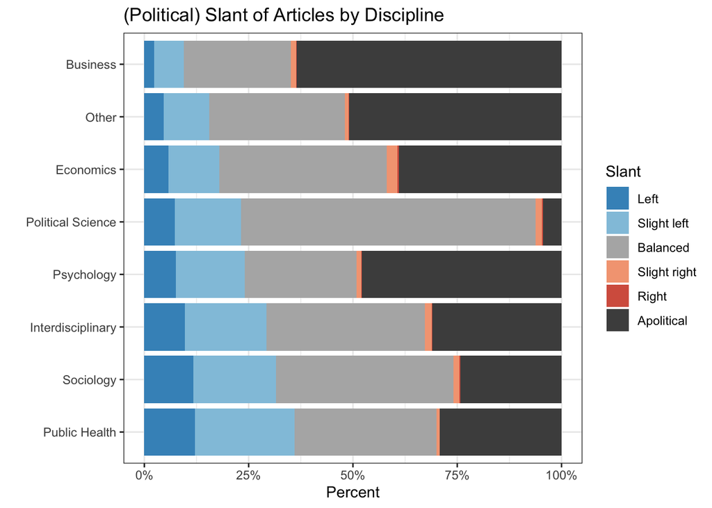

```r
df <- df %>%
  mutate(Slant = case_when(
    Slant == 1 ~ 2,
    Slant == 7 ~ 6,
    TRUE ~ Slant
  ))

slant_cols  <- c(
  "Left"        = "#4393c3",
  "Slight left" = "#92c5de",
  "Balanced"    = "gray70",
  "Slight right"= "#f4a582",
  "Right"       = "#d6604d",
  "Apolitical"  = "gray30"
)

slant_by_disc <- df %>%
  mutate(
    Discipline = dplyr::recode(
      Discipline,
      "B"  = "Business",
      "E"  = "Economics",
      "I"  = "Interdisciplinary",
      "O"  = "Other",
      "P"  = "Psychology",
      "PH" = "Public Health",
      "PS" = "Political Science",
      "S"  = "Sociology",
      .default = Discipline
    ),
    Slant = tidyr::replace_na(Slant, 7L),
    Slant = Slant - 1
  ) %>%
  count(Discipline, Slant) %>%
  complete(Discipline, Slant = 1:6, fill = list(n = 0)) %>%
  mutate(
    Slant = factor(
      Slant, levels = 1:6,
      labels = c("Left","Slight left","Balanced","Slight right","Right","Apolitical")
    )
  )


# Order by share of "Left"
left_share <- slant_by_disc %>%
  group_by(Discipline) %>%
  summarise(pct_left = sum(n[Slant == "Left"], na.rm = TRUE) / sum(n), .groups = "drop")

slant_by_disc <- slant_by_disc %>%
  left_join(left_share, by = "Discipline") %>%
  mutate(Discipline = fct_reorder(Discipline, pct_left, .desc = TRUE))

# Plot as percentages
ggplot(slant_by_disc, aes(x = Discipline, y = n, fill = Slant)) +
  geom_col(position = position_fill(reverse = TRUE)) +
  scale_y_continuous(labels = percent_format(accuracy = 1)) +
  scale_fill_manual(values = slant_cols) +
  coord_flip() +
  labs(
    title = "(Political) Slant of Articles by Discipline",
    y = "Percent", x = ""
  ) +
  theme_bw()
```

```r
ggsave('figures/slant_by_discipline.png', height=3, width=6)


table(df$Discipline,df$Rating)
```

```
##
##          A     P
##   B  33983 19583
##   E  12110 18945
##   I   3688  8213
##   O  14602 14091
##   P   6508  7099
##   PH  7972 19369
##   PS   400  8527
##   S   4734 14782
```

```r
table(df$Discipline,df$Slant)
```

```
##
##          2     3     4     5     6
##   B   1267  3783 13741   698    94
##   E   1813  3762 12457   783   130
##   I   1158  2320  4527   186    22
##   O   1338  3135  9317   256    45
##   P   1020  2260  3632   168    19
##   PH  3310  6542  9305   195    17
##   PS   651  1422  6300   132    22
##   S   2298  3858  8313   270    43
```

Proportion leftish by discipline and decade (Not included)

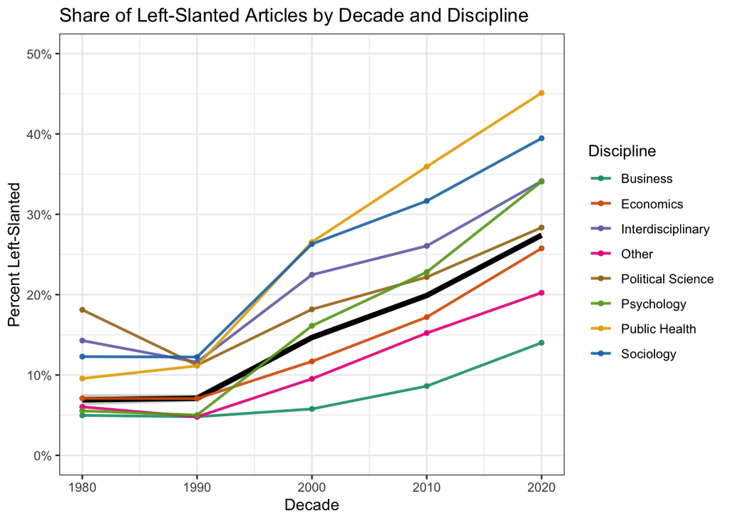

```r
leftish_levels <- c("Left","Slight left")

df_prepped <- df %>%
  mutate(
    Discipline = dplyr::recode(
      Discipline,
      "B"  = "Business",
      "E"  = "Economics",
      "I"  = "Interdisciplinary",
      "O"  = "Other",
      "P"  = "Psychology",
      "PH" = "Public Health",
      "PS" = "Political Science",
      "S"  = "Sociology",
      .default = Discipline
    ),
    Slant_collapsed = dplyr::case_when(
      is.na(Slant)      ~ "Apolitical",
      Slant %in% c(1,2) ~ "Left",
      Slant == 3        ~ "Slight left",
      Slant == 4        ~ "Balanced",
      Slant == 5        ~ "Slight right",
      Slant %in% c(6,7) ~ "Right",
      TRUE              ~ "Apolitical"
    ),
    Leftish  = Slant_collapsed %in% leftish_levels,
    Recorded = TRUE
  ) %>%
  filter(!is.na(Decade), Decade >= 1980, Decade <= 2020)

disc_decade <- df_prepped %>%
  group_by(Discipline, Decade) %>%
  summarise(
    n_leftish = sum(Leftish, na.rm = TRUE),
    n_total   = sum(Recorded, na.rm = TRUE),
    prop_leftish = ifelse(n_total > 0, n_leftish / n_total, NA_real_),
    .groups = "drop"
  ) %>%
  arrange(Decade, Discipline)

# Overall decade proportions + 95% Wilson CI
overall_decade <- df_prepped %>%
  group_by(Decade) %>%
  summarise(
    n_leftish = sum(Leftish, na.rm = TRUE),
    n_total   = sum(Recorded, na.rm = TRUE),
    prop_leftish = ifelse(n_total > 0, n_leftish / n_total, NA_real_),
    .groups = "drop"
  ) %>%
  mutate(
    z = 1.96,
    denom  = 1 + (z^2 / n_total),
    center = (prop_leftish + (z^2 / (2*n_total))) / denom,
    half   = z * sqrt((prop_leftish*(1 - prop_leftish) + (z^2/(4*n_total))) / n_total) / denom,
    lower  = pmax(0, center - half),
    upper  = pmin(1, center + half)
  )

# (Optional) nice discipline colors
disc_cols <- c(
  "Business" = "#1b9e77",
  "Economics" = "#d95f02",
  "Interdisciplinary" = "#7570b3",
  "Other" = "#e7298a",
  "Psychology" = "#66a61e",
  "Public Health" = "#e6ab02",
  "Political Science" = "#a6761d",
  "Sociology" = "#1f78b4"
)

# Plot: discipline lines + overall black line with CI band
overall_decade$Decade <- as.numeric(as.character(overall_decade$Decade))
disc_decade$Decade <- as.numeric(as.character(disc_decade$Decade))
ggplot() +
  geom_ribbon(
    data = overall_decade,
    aes(x = Decade, ymin = lower, ymax = upper),
    fill = "black", alpha = 0.2
  ) +
  geom_line(  # ~3× thicker
    data = overall_decade,
    aes(x = Decade, y = prop_leftish),
    color = "black", linewidth = 1.75
  ) +
  geom_line(
    data = disc_decade,
    aes(x = Decade, y = prop_leftish, color = Discipline, group = Discipline),
    linewidth = 0.9, alpha = 0.9
  ) +
  geom_point(
    data = disc_decade,
    aes(x = Decade, y = prop_leftish, color = Discipline),
    size = 1.25, alpha = 0.9
  ) +
  scale_x_continuous(breaks = seq(1980, max(disc_decade$Decade, na.rm = TRUE), by = 10)) +
  scale_y_continuous(labels = percent_format(accuracy = 1), limits = c(0, 0.5)) +
  scale_color_manual(values = disc_cols) +
  labs(
    title = "Share of Left-Slanted Articles by Decade and Discipline",
    x = "Decade",
    y = "Percent Left-Slanted",
    color = "Discipline"
  ) +
  theme_bw()
```

```r
ggsave('figures/leftish_by_discipline.png', height=3, width=6)
```

Proportion causal by discipline and slant (Figure S3)

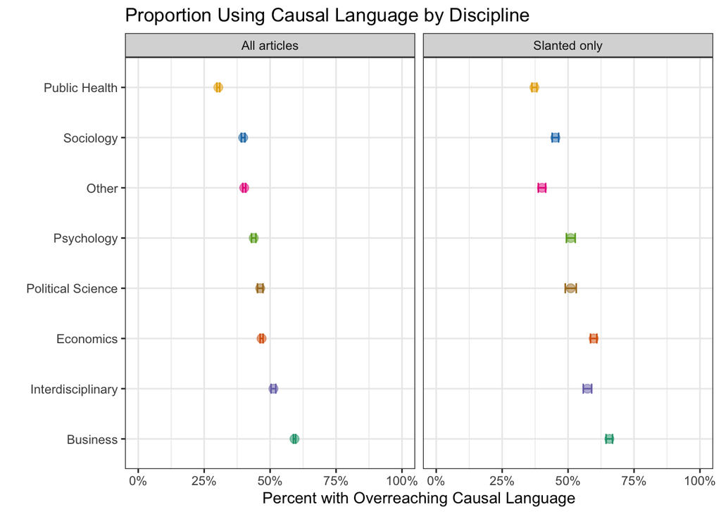

```r
df_prepped <- df %>%
  mutate(
    Discipline = dplyr::recode(
      Discipline,
      "B"="Business","E"="Economics","I"="Interdisciplinary","O"="Other",
      "P"="Psychology","PH"="Public Health","PS"="Political Science","S"="Sociology",
      .default = Discipline
    ),
    Slant_collapsed = dplyr::case_when(
      is.na(Slant)      ~ "Apolitical",
      Slant %in% c(1,2) ~ "Left",
      Slant == 3        ~ "Slight left",
      Slant == 4        ~ "Balanced",
      Slant == 5        ~ "Slight right",
      Slant %in% c(6,7) ~ "Right",
      TRUE              ~ "Apolitical"
    ),
    CausalFlag = as.logical(Causal)   # works for 0/1 or TRUE/FALSE
  )


# 2) Helper to add Wilson 95% CI
add_wilson <- function(d){
  d %>%
    mutate(
      prop = ifelse(n_tot > 0, n_causal / n_tot, NA_real_),
      z = 1.96,
      denom = 1 + (z^2 / n_tot),
      center = (prop + (z^2 / (2*n_tot))) / denom,
      half   = z * sqrt((prop*(1 - prop) + (z^2/(4*n_tot))) / n_tot) / denom,
      lower  = pmax(0, center - half),
      upper  = pmin(1, center + half)
    ) %>%
    select(-z, -denom, -center, -half)
}

# 3) Overall by discipline
overall_by_disc <- df_prepped %>%
  group_by(Discipline) %>%
  summarise(
    n_causal = sum(CausalFlag, na.rm = TRUE),
    n_tot    = sum(!is.na(CausalFlag)),
    .groups = "drop"
  ) %>%
  add_wilson() %>%
  mutate(Subset = "All articles")

# 4) Slanted-only (exclude Balanced & Apolitical)
slanted_by_disc <- df_prepped %>%
  filter(Slant_collapsed %in% c("Left","Slight left","Slight right","Right")) %>%
  group_by(Discipline) %>%
  summarise(
    n_causal = sum(CausalFlag, na.rm = TRUE),
    n_tot    = sum(!is.na(CausalFlag)),
    .groups = "drop"
  ) %>%
  add_wilson() %>%
  mutate(Subset = "Slanted only")

# 5) Combine + order disciplines by overall proportion
both <- bind_rows(overall_by_disc, slanted_by_disc)
disc_order <- overall_by_disc %>% arrange(desc(prop)) %>% pull(Discipline)
both <- both %>% mutate(
  Discipline = factor(Discipline, levels = disc_order),
  Subset = factor(Subset, levels = c("All articles","Slanted only"))
)

# Optional: reuse your palette, else comment this out
disc_cols <- c(
  "Business" = "#1b9e77","Economics" = "#d95f02","Interdisciplinary" = "#7570b3",
  "Other" = "#e7298a","Psychology" = "#66a61e","Public Health" = "#e6ab02",
  "Political Science" = "#a6761d","Sociology" = "#1f78b4"
)

# 6) Plot (point + 95% CI), side-by-side
ggplot(both, aes(x = Discipline, y = prop, color = Discipline)) +
  geom_errorbar(aes(ymin = lower, ymax = upper), width = 0.2, alpha = 1) +
  geom_point(size = 2.6, alpha = 0.5) +
  coord_flip() +
  facet_wrap(~ Subset, nrow = 1) +
  scale_y_continuous(labels = percent_format(accuracy = 1), limits = c(0, 1)) +
  scale_color_manual(values = disc_cols, guide = "none") +
  labs(
    title = "Proportion Using Causal Language by Discipline",
    x = "", y = "Percent with Overreaching Causal Language"
  ) +
  theme_bw()
```

```r
ggsave('figures/causal_by_discipline.png', height=3, width=6)
```

Difference in proportion (Not included)

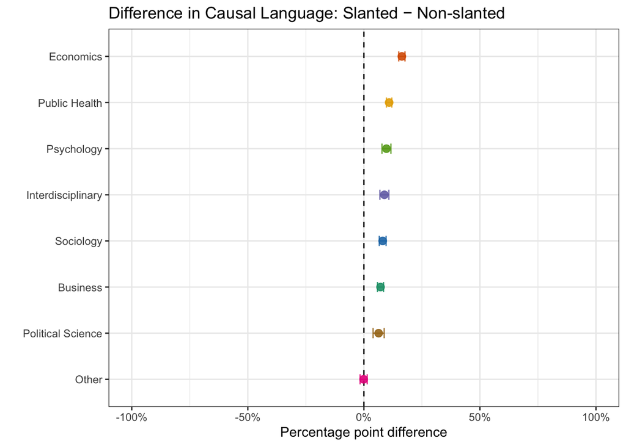

```r
diff_disc <- df_prepped %>%
  mutate(
    Slanted     = Slant_collapsed %in% c("Left","Slight left","Slight right","Right"),
    NonSlanted  = Slant_collapsed %in% c("Balanced","Apolitical")
  ) %>%
  group_by(Discipline) %>%
  summarise(
    x1 = sum(CausalFlag & Slanted, na.rm = TRUE),
    n1 = sum(Slanted & !is.na(CausalFlag)),
    x0 = sum(CausalFlag & NonSlanted, na.rm = TRUE),
    n0 = sum(NonSlanted & !is.na(CausalFlag)),
    p1 = ifelse(n1 > 0, x1 / n1, NA_real_),
    p0 = ifelse(n0 > 0, x0 / n0, NA_real_),
    diff  = p1 - p0,
    se    = sqrt(ifelse(n1 > 0, p1 * (1 - p1) / n1, 0) +
                 ifelse(n0 > 0, p0 * (1 - p0) / n0, 0)),
    lower = pmax(-1, diff - 1.96 * se),
    upper = pmin( 1, diff + 1.96 * se),
    .groups = "drop"
  ) %>%
  filter(!is.na(diff)) %>%
  mutate(Discipline = fct_reorder(Discipline, diff))

# Plot (positive = slanted uses more causal language than non-slanted)
ggplot(diff_disc, aes(y = Discipline, x = diff, color = Discipline)) +
  geom_vline(xintercept = 0, linetype = "dashed") +
  geom_errorbarh(aes(xmin = lower, xmax = upper), height = 0.22, alpha = 0.85) +
  geom_point(size = 2.6, alpha = 0.9) +
  scale_x_continuous(labels = percent_format(accuracy = 1), limits = c(-1, 1)) +
  scale_color_manual(values = disc_cols, guide = "none") +
  labs(
    title = "Difference in Causal Language: Slanted − Non-slanted",
    x = "Percentage point difference",
    y = ""
  ) +
  theme_bw()
```